# Ambulatory or residential? a multi-state analysis of treatments for substance use disorders (Step 2)

```r
lmaj_res_1_365<-
LMAJ(pr1_sel, #An "msdata" object, as for instance prepared by link{msprep}
                  from=1, ##Either a single state or a set of states in the state space 1,...,S
                  s=365,  #The prediction time point s from which transition probabilities are to be obtained
                  method ="aalen" #The method for calculating variances, as in probtrans
                  )
lmaj_res_2_365<-
LMAJ(pr1_sel, #An "msdata" object, as for instance prepared by link{msprep}
                  from=2, ##Either a single state or a set of states in the state space 1,...,S
                  s=365,  #The prediction time point s from which transition probabilities are to be obtained
                  method ="aalen" #The method for calculating variances, as in probtrans
                  )
lmaj_res_3_365<-
LMAJ(pr1_sel, #An "msdata" object, as for instance prepared by link{msprep}
                  from=3, ##Either a single state or a set of states in the state space 1,...,S
                  s=365,  #The prediction time point s from which transition probabilities are to be obtained
                  method ="aalen" #The method for calculating variances, as in probtrans
                  )
lmaj_res_4_365<-
LMAJ(pr1_sel, #An "msdata" object, as for instance prepared by link{msprep}
                  from=4, ##Either a single state or a set of states in the state space 1,...,S
                  s=365,  #The prediction time point s from which transition probabilities are to be obtained
                  method ="aalen" #The method for calculating variances, as in probtrans
                  )
```

```
## Error in data.frame(time = sf0$time, Haz = -log(sf0$surv), norisk = norisk, : arguments imply differing number of rows: 2, 0
```

```r
#_#_#_#_#_#_#_#_#_#_#_#_#_#_#_#_#_#_#_#_#_#_#_#_#_#_#_#_#_#_#_#_#_#_#_
#_#_#_#_#_#_#_#_#_#_#_#_#_#_#_#_#_#_#_#_#_#_#_#_#_#_#_#_#_#_#_#_#_#_#_
#_#_#_#_#_#_#_#_#_#_#_#_#_#_#_#_#_#_#_#_#_#_#_#_#_#_#_#_#_#_#_#_#_#_#_

lmaj_out_1_365<-
LMAJ(pr0_sel, #An "msdata" object, as for instance prepared by link{msprep}
                  from=1, ##Either a single state or a set of states in the state space 1,...,S
                  s=365,  #The prediction time point s from which transition probabilities are to be obtained
                  method ="aalen" #The method for calculating variances, as in probtrans
                  )
lmaj_out_2_365<-
LMAJ(pr0_sel, #An "msdata" object, as for instance prepared by link{msprep}
                  from=2, ##Either a single state or a set of states in the state space 1,...,S
                  s=365,  #The prediction time point s from which transition probabilities are to be obtained
                  method ="aalen" #The method for calculating variances, as in probtrans
                  )
lmaj_out_3_365<-
LMAJ(pr0_sel, #An "msdata" object, as for instance prepared by link{msprep}
                  from=3, ##Either a single state or a set of states in the state space 1,...,S
                  s=365,  #The prediction time point s from which transition probabilities are to be obtained
                  method ="aalen" #The method for calculating variances, as in probtrans
                  )
lmaj_out_4_365<-
LMAJ(pr0_sel, #An "msdata" object, as for instance prepared by link{msprep}
                  from=4, ##Either a single state or a set of states in the state space 1,...,S
                  s=365,  #The prediction time point s from which transition probabilities are to be obtained
                  method ="aalen" #The method for calculating variances, as in probtrans
                  )
```

```
## Error in data.frame(time = sf0$time, Haz = -log(sf0$surv), norisk = norisk, : arguments imply differing number of rows: 1, 0
```

```r
lmaj_res_1_365<-
LMAJ(pr1_sel, #An "msdata" object, as for instance prepared by link{msprep}
                  from=1, ##Either a single state or a set of states in the state space 1,...,S
                  s=365,  #The prediction time point s from which transition probabilities are to be obtained
                  method ="aalen" #The method for calculating variances, as in probtrans
                  )
lmaj_res_2_365<-
LMAJ(pr1_sel, #An "msdata" object, as for instance prepared by link{msprep}
                  from=2, ##Either a single state or a set of states in the state space 1,...,S
                  s=365,  #The prediction time point s from which transition probabilities are to be obtained
                  method ="aalen" #The method for calculating variances, as in probtrans
                  )
lmaj_res_3_365<-
LMAJ(pr1_sel, #An "msdata" object, as for instance prepared by link{msprep}
                  from=3, ##Either a single state or a set of states in the state space 1,...,S
                  s=365,  #The prediction time point s from which transition probabilities are to be obtained
                  method ="aalen" #The method for calculating variances, as in probtrans
                  )
lmaj_res_4_365<-
LMAJ(pr1_sel, #An "msdata" object, as for instance prepared by link{msprep}
                  from=4, ##Either a single state or a set of states in the state space 1,...,S
                  s=365,  #The prediction time point s from which transition probabilities are to be obtained
                  method ="aalen" #The method for calculating variances, as in probtrans
                  )
```

```
## Error in data.frame(time = sf0$time, Haz = -log(sf0$surv), norisk = norisk, : arguments imply differing number of rows: 2, 0
```

```r
#_#_#_#_#_#_#_#_#_#_#_#_#_#_#_#_#_#_#_#_#_#_#_#_#_#_#_#_#_#_#_#_#_#_#_
#_#_#_#_#_#_#_#_#_#_#_#_#_#_#_#_#_#_#_#_#_#_#_#_#_#_#_#_#_#_#_#_#_#_#_
#_#_#_#_#_#_#_#_#_#_#_#_#_#_#_#_#_#_#_#_#_#_#_#_#_#_#_#_#_#_#_#_#_#_#_

lmaj_out_1_1095<-
LMAJ(pr0_sel, #An "msdata" object, as for instance prepared by link{msprep}
                  from=1, ##Either a single state or a set of states in the state space 1,...,S
                  s=365*3,  #The prediction time point s from which transition probabilities are to be obtained
                  method ="aalen" #The method for calculating variances, as in probtrans
                  )
lmaj_out_2_1095<-
LMAJ(pr0_sel, #An "msdata" object, as for instance prepared by link{msprep}
                  from=2, ##Either a single state or a set of states in the state space 1,...,S
                  s=365*3,  #The prediction time point s from which transition probabilities are to be obtained
                  method ="aalen" #The method for calculating variances, as in probtrans
                  )
lmaj_out_3_1095<-
LMAJ(pr0_sel, #An "msdata" object, as for instance prepared by link{msprep}
                  from=3, ##Either a single state or a set of states in the state space 1,...,S
                  s=365*3,  #The prediction time point s from which transition probabilities are to be obtained
                  method ="aalen" #The method for calculating variances, as in probtrans
                  )
lmaj_out_4_1095<-
LMAJ(pr0_sel, #An "msdata" object, as for instance prepared by link{msprep}
                  from=4, ##Either a single state or a set of states in the state space 1,...,S
                  s=365*3,  #The prediction time point s from which transition probabilities are to be obtained
                  method ="aalen" #The method for calculating variances, as in probtrans
                  )
```

```
## Error in data.frame(time = sf0$time, Haz = -log(sf0$surv), norisk = norisk, : arguments imply differing number of rows: 19, 0
```

```r
lmaj_res_1_1095<-
LMAJ(pr1_sel, #An "msdata" object, as for instance prepared by link{msprep}
                  from=1, ##Either a single state or a set of states in the state space 1,...,S
                  s=365*3,  #The prediction time point s from which transition probabilities are to be obtained
                  method ="aalen" #The method for calculating variances, as in probtrans
                  )
lmaj_res_2_1095<-
LMAJ(pr1_sel, #An "msdata" object, as for instance prepared by link{msprep}
                  from=2, ##Either a single state or a set of states in the state space 1,...,S
                  s=365*3,  #The prediction time point s from which transition probabilities are to be obtained
                  method ="aalen" #The method for calculating variances, as in probtrans
                  )
lmaj_res_3_1095<-
LMAJ(pr1_sel, #An "msdata" object, as for instance prepared by link{msprep}
                  from=3, ##Either a single state or a set of states in the state space 1,...,S
                  s=365*3,  #The prediction time point s from which transition probabilities are to be obtained
                  method ="aalen" #The method for calculating variances, as in probtrans
                  )
lmaj_res_4_1095<-
LMAJ(pr1_sel, #An "msdata" object, as for instance prepared by link{msprep}
                  from=4, ##Either a single state or a set of states in the state space 1,...,S
                  s=365*3,  #The prediction time point s from which transition probabilities are to be obtained
                  method ="aalen" #The method for calculating variances, as in probtrans
                  )
```

```
## Error in data.frame(time = sf0$time, Haz = -log(sf0$surv), norisk = norisk, : arguments imply differing number of rows: 35, 0
```

```r
#if (nrow(mf) ==0) stop("No (non-missing) observations")

time_after_LMAJ<-Sys.time()

#LMAJ(pr1,from=1,s=90,method="aalen")

paste0("Time in process: ");time_after_LMAJ-time_before_LMAJ
```

```
## [1] "Time in process: "
```

```
## Time difference of 23.02585 secs
```

```r
LMAJ2<-function (msdata, s, from, method = c("aalen", "greenwood"))
{
  tmat <- attr(msdata, "trans")
  if (is.null(tmat))
    stop("msdata object should have a \"trans\" attribute")
  K <- nrow(tmat)
  if (any(is.na(match(from, 1:K))))
    stop("from should be subset of 1:K with K number of states")
  xss <- xsect(msdata, s)
  infrom <- xss$id[xss$state %in% from]
  msdatas <- cutLMms(msdata, LM = s)
  msdatasfrom <- msdatas[msdatas$id %in% infrom, ]

  c0 <- coxph(Surv(Tstart, Tstop, status) ~ strata(trans),
              data = msdatasfrom)
  msf0 <- msfit2(c0, trans = tmat)
  pt0 <- probtrans(msf0, predt = s, method = method)[from]
  if (length(from) == 1)
    return(pt0[[1]])
  else {
    xsss <- xss[xss$state %in% from, ]
    xsss$state <- factor(xsss$state, levels = from)
    tbl <- table(xsss$state)
    p <- tbl/sum(tbl)
    varp <- (diag(p) - p %*% t(p))/sum(tbl)
    res <- tmp1 <- tmp2 <- 0
    for (j in 1:length(from)) {
      ptj <- pt0[[j]]
      res <- res + p[j] * ptj[, 1 + (1:K)]
      tmp2 <- tmp2 + p[j] * (1 - p[j]) * (ptj[, K + 1 +
                                                (1:K)])^2
      for (k in 1:length(from)) {
        ptk <- pt0[[k]]
        tmp1 <- tmp1 + varp[j, k] * ptj[, 1 + (1:K)] *
          ptk[, 1 + (1:K)]
      }
    }
    ses <- sqrt(tmp1 + tmp2)
    pt <- ptj
    pt[, 1 + (1:K)] <- res
    pt[, K + 1 + (1:K)] <- ses
    return(pt)
  }
}

msfit2<-function (object, newdata, variance = TRUE, vartype = c("aalen",
                                                                "greenwood"), trans)
{
  if (!is.null((object$call)$weights) || !is.null(object$weights))
    stop("msfit cannot (yet) compute the result for a weighted model")
  Terms <- terms(object)
  strat <- attr(Terms, "specials")$strata
  cluster <- attr(Terms, "specials")$cluster
  if (length(cluster))
    stop("cluster terms are not supported")
  if (!is.null(attr(object$terms, "specials")$tt))
    stop("msfit cannot yet process coxph models with a tt term")
  resp <- attr(Terms, "variables")[attr(Terms, "response")]
  nvar <- length(object$coefficients)
  score <- exp(object$linear.predictors)
  vartype <- match.arg(vartype)
  if (is.na(vartype))
    stop("Invalid variance type specified")
  has.strata <- !is.null(attr(object$terms, "specials")$strata)
  if (is.null(object$y) || is.null(object[["x"]]) ||
      !is.null(object$call$weights) || (has.strata && is.null(object$strata)) ||
      !is.null(attr(object$terms, "offset"))) {
    mf <- model.frame(object)
  }
  else mf <- NULL
  if (is.null(mf))
    y <- object[["y"]]
  else {
    y <- model.response(mf)
    y2 <- object[["y"]]
    if (!is.null(y2) && any(dim(y2) != dim(y)))
      stop("Could not reconstruct the y vector")
  }
  if (is.null(object[["x"]]))
    x <- model.matrix(object, data = mf)
  else x <- object[["x"]]
  n <- nrow(y)
  if (n != object$n[1] || nrow(x) != n)
    stop("Failed to reconstruct the original data set")
  type <- attr(y, "type")
  if (type == "counting")
    lasty <- max(y[, 2])
  else if (type == "right")
    lasty <- max(y[, 1])
  else stop("Cannot handle \"", type, "\" type survival data")
  if (is.null(mf))
    offset <- 0
  else {
    offset <- model.offset(mf)
    if (is.null(offset))
      offset <- 0
  }
  Terms <- object$terms
  if (!has.strata)
    strata <- rep(0L, n)
  else {
    stangle <- untangle.specials(Terms, "strata")
    strata <- object$strata
    if (is.null(strata)) {
      if (length(stangle$vars) == 1)
        strata <- mf[[stangle$vars]]
      else strata <- strata(mf[, stangle$vars], shortlabel = TRUE)
    }
  }
  if (has.strata) {
    temp <- attr(Terms, "specials")$strata
    factors <- attr(Terms, "factors")[temp, ]
    strata.interaction <- any(t(factors) * attr(Terms, "order") >
                                1)
    if (strata.interaction)
      stop("Interaction terms with strata not supported")
  }
  if (vartype == "greenwood") {
    if (missing(trans))
      stop("argument trans missing; needed for vartype=\"greenwood\"")
    labels <- attr(Terms, "term.labels")
    if (length(labels) != 1)
      stop("Invalid formula for greenwood, ~strata(trans) needed, no covariates allowed")
    if (attr(Terms, "term.labels") != "strata(trans)")
      stop("Invalid formula for greenwood, ~strata(trans) needed, no covariates allowed")
    sf0 <- summary(survfit(object))
    norisk <- sf0$n.risk
    noevent <- sf0$n.event


    if(is.null(sf0$strata)){

      sf0$strata<-rep(max(trans, na.rm = T),length(noevent))

    }

    length(norisk)
    length(noevent)
    as.numeric(sf0$strata)

    length(as.numeric(sf0$strata))



    sf0 <- data.frame(time = sf0$time, Haz = -log(sf0$surv),
                      norisk = norisk, noevent = noevent, trans = as.numeric(sf0$strata))



    allt <- sort(unique(c(sf0$time, lasty)))
    nt <- length(allt)
    K <- nrow(to.trans2(trans))
    Haz <- data.frame(time = rep(allt, K), Haz = NA, trans = rep(1:K,
                                                                 rep(nt, K)))
    if (variance) {
      tr12 <- data.frame(trans1 = rep(1:K, rep(K, K)),
                         trans2 = rep(1:K, K))
      tr12 <- tr12[tr12$trans1 <= tr12$trans2, ]
      varHaz <- data.frame(time = rep(allt, K * (K + 1)/2),
                           varHaz = 0, trans1 = rep(tr12$trans1, rep(nt,
                                                                     K * (K + 1)/2)), trans2 = rep(tr12$trans2,
                                                                                                   rep(nt, K * (K + 1)/2)))
    }
    S <- nrow(trans)
    for (s in 1:S) {
      trs <- trans[s, ]
      trs <- trs[!is.na(trs)]
      ntrs <- length(trs)
      if (ntrs > 0) {
        for (i in 1:ntrs) {
          trans1 <- trs[i]
          sf1 <- sf0[sf0$trans == trans1, ]
          Haz$Haz[(trans1 - 1) * nt + match(sf1$time,
                                            allt)] <- sf1$Haz
          Haz$Haz[(trans1 - 1) * nt + 1:nt] <- NAfix2(Haz$Haz[(trans1 -
                                                                1) * nt + 1:nt], subst = 0)
          if (variance) {
            varHaz1 <- cumsum((sf1$norisk - sf1$noevent) *
                                sf1$noevent/sf1$norisk^3)
            varHaz11 <- varHaz[varHaz$trans1 == trans1 &
                                 varHaz$trans2 == trans1, ]
            varHaz11$varHaz <- NA
            varHaz11$varHaz[match(sf1$time, allt)] <- varHaz1
            varHaz11$varHaz <- NAfix2(varHaz11$varHaz,
                                     subst = 0)
            varHaz[varHaz$trans1 == trans1 & varHaz$trans2 ==
                     trans1, ] <- varHaz11
            if (i < ntrs) {
              for (j in ((i + 1):ntrs)) {
                trans2 <- trs[j]
                sf2 <- sf0[sf0$trans == trans2, ]
                jointt <- intersect(sf1$time, sf2$time)
                if (length(jointt) > 0) {
                  varHazij <- rep(NA, length(jointt))
                  ik <- match(jointt, sf1$time)
                  jk <- match(jointt, sf2$time)
                  varHazij <- cumsum(-sf1$noevent[ik] *
                                       sf2$noevent[jk]/sf1$norisk[ik]^3)
                  varHaz12 <- varHaz[varHaz$trans1 ==
                                       trans1 & varHaz$trans2 == trans2,
                                     ]
                  varHaz12$varHaz <- NA
                  varHaz12$varHaz[match(jointt, allt)] <- varHazij
                  varHaz12$varHaz <- NAfix2(varHaz12$varHaz,
                                           subst = 0)
                  varHaz[varHaz$trans1 == trans1 & varHaz$trans2 ==
                           trans2, ] <- varHaz12
                }
              }
            }
          }
        }
      }
    }
  }
  else {
    labels <- attr(Terms, "term.labels")
    if (length(labels) == 1) {
      if (labels == "strata(trans)") {
        sf0 <- summary(survfit(object))
        norisk <- sf0$n.risk
        noevent <- sf0$n.event
```

```r
        if(is.null(sf0$strata)){

          sf0$strata<-rep(max(trans, na.rm = T),length(noevent))

        }

        sf0 <- data.frame(time = sf0$time, Haz = -log(sf0$surv),
                          norisk = norisk, noevent = noevent, var = sf0$std.err^2/(sf0$surv)^2,
                          trans = as.numeric(sf0$strata))
        allt <- sort(unique(c(sf0$time, lasty)))
        nt <- length(allt)
        K <- max(sf0$trans)
        Haz <- data.frame(time = rep(allt, K), Haz = NA,
                          trans = rep(1:K, rep(nt, K)))
        if (variance) {
          tr12 <- data.frame(trans1 = rep(1:K, rep(K,
                                                   K)), trans2 = rep(1:K, K))
          tr12 <- tr12[tr12$trans1 <= tr12$trans2, ]
          varHaz <- data.frame(time = rep(allt, K * (K +
                                                       1)/2), varHaz = 0, trans1 = rep(tr12$trans1,
                                                                                       rep(nt, K * (K + 1)/2)), trans2 = rep(tr12$trans2,
                                                                                                                             rep(nt, K * (K + 1)/2)))
        }
        for (k in 1:K) {
          sfk <- sf0[sf0$trans == k, ]
          wht <- match(sfk$time, allt)
          Hazk <- Haz[Haz$trans == k, ]
          Hazk$Haz[wht] <- sfk$Haz
          Hazk$Haz <- NAfix2(Hazk$Haz, subst = 0)
          Haz[Haz$trans == k, ] <- Hazk
          if (variance) {
            varHazkk <- varHaz[varHaz$trans1 == k & varHaz$trans2 ==
                                 k, ]
            varHazkk$varHaz <- NA
            varHazkk$varHaz[wht] <- sfk$var
            varHazkk$varHaz <- NAfix2(varHazkk$varHaz,
                                     subst = 0)
            varHaz[varHaz$trans1 == k & varHaz$trans2 ==
                     k, ] <- varHazkk
          }
        }
      }
    }
    else {
      method <- object$method
      if (method == "breslow")
        method <- 1
      else if (method == "efron")
        method <- 2
      else stop("Only \"efron\" and \"breslow\" methods for ties supported")
      type <- attr(y, "type")
      if (type == "counting") {
        if (has.strata)
          ord <- order(mf[, strat], y[, 2], -y[, 3])
        else ord <- order(y[, 2], -y[, 3])
      }
      else if (type == "right") {
        if (has.strata)
          ord <- order(mf[, strat], y[, 1], -y[, 2])
        else ord <- order(y[, 1], -y[, 2])
        miny <- min(y[, 1])
        if (miny < 0)
          y <- cbind(2 * miny - 1, y)
        else y <- cbind(-1, y)
      }
      else stop("Cannot handle \"", type, "\" type survival data")
      if (variance)
        x <- x[ord, ]
      else x <- 0
      if (has.strata)
        newstrat <- (as.numeric(mf[, strat]))[ord]
      else newstrat <- rep(1, n)
      newstrat <- cumsum(table(newstrat))
      H <- length(newstrat)
      subterms <- function(tt, i) {
        dataClasses <- attr(tt, "dataClasses")
        predvars <- attr(tt, "predvars")
        oldnames <- dimnames(attr(tt, "factors"))[[1]]
        tt <- tt[i]
        index <- match(dimnames(attr(tt, "factors"))[[1]],
                       oldnames)
        if (length(index) > 0) {
          if (!is.null(predvars))
            attr(tt, "predvars") <- predvars[c(1,
                                               index + 1)]
          if (!is.null(dataClasses))
            attr(tt, "dataClasses") <- dataClasses[index]
        }
        tt
      }
      if (has.strata) {
        temp <- untangle.specials(Terms, "strata")
        if (length(temp$vars))
          Terms <- subterms(Terms, -temp$terms)
      }
      Terms2 <- delete.response(Terms)
      if (has.strata) {
        if (length(attr(Terms2, "specials")$strata))
          Terms2 <- subterms(Terms2, -attr(Terms2, "specials")$strata)
        if (!is.null(object$xlevels)) {
          myxlev <- object$xlevels[match(attr(Terms2,
                                              "term.labels"), names(object$xlevels),
                                         nomatch = 0)]
          if (length(myxlev) == 0)
            myxlev <- NULL
        }
        else myxlev <- NULL
        mf2 <- model.frame(Terms2, data = newdata, xlev = myxlev)
      }
      else mf2 <- model.frame(Terms2, data = newdata, xlev = object$xlevels)
      offset2 <- 0
      if (!missing(newdata)) {
        offset2 <- model.offset(mf2)
        if (length(offset2) > 0)
          offset2 <- offset2 - mean(offset)
        else offset2 <- 0
        x2 <- model.matrix(Terms2, mf2)[, -1, drop = FALSE]
      }
      else stop("newdata missing")
      if (has.strata & is.null(newdata$strata))
        stop("no \"strata\" column present in newdata")
      n2 <- nrow(x2)
      coef <- ifelse(is.na(object$coefficients), 0, object$coefficients)
      newrisk <- exp(c(x2 %*% coef) + offset2 - sum(coef *
                                                      object$means))
      dimnames(y) <- NULL
      storage.mode(y) <- "double"
      ndead <- sum(y[, 3])
      untimes <- sort(unique(y[, 2][y[, 3] == 1]))
      nt <- length(untimes)
      surv <- .C("agmssurv", sn = as.integer(n),
                 sp = as.integer(nvar), svar = as.integer(variance),
                 smethod = as.integer(method), sH = as.integer(H),
                 sK = as.integer(n2), snt = as.integer(nt), y = y[ord,
                                                                  ], score = as.double(score[ord]), xmat = as.double(x),
                 varcov = as.double(object$var), strata = as.integer(c(0,
                                                                       newstrat)), kstrata = as.integer(newdata$strata),
                 unt = as.double(untimes), newx = as.double(x2),
                 newrisk = as.double(newrisk), Haz = double(nt *
                                                              n2), varHaz = double(nt * n2 * (n2 + 1)/2),
                 d = double(3 * nvar), work = double(nt * n2 *
                                                       (nvar + 1)))
      Haz <- data.frame(time = rep(untimes, n2), Haz = surv$Haz,
                        trans = rep(1:n2, rep(nt, n2)))
      varHaz <- as.vector(t(matrix(surv$varHaz, ncol = nt)))
      hlp <- matrix(c(rep(1:n2, rep(n2, n2)), rep(1:n2,
                                                  n2)), n2^2, 2)
      hlp <- hlp[hlp[, 1] <= hlp[, 2], ]
      varHaz <- data.frame(time = rep(untimes, n2 * (n2 +
                                                       1)/2), varHaz = varHaz, trans1 = rep(hlp[, 1],
                                                                                            rep(nt, n2 * (n2 + 1)/2)), trans2 = rep(hlp[,
                                                                                                                                        2], rep(nt, n2 * (n2 + 1)/2)))
      if (lasty > max(untimes)) {
        Hmat <- matrix(Haz$Haz, nrow = nt)
        Hmat <- rbind(Hmat, Hmat[nt, ])
        vHmat <- matrix(varHaz$varHaz, nrow = nt)
        vHmat <- rbind(vHmat, vHmat[nt, ])
        untimes <- c(untimes, lasty)
        nt <- nt + 1
        Haz <- data.frame(time = rep(untimes, n2), Haz = as.vector(Hmat),
                          trans = rep(1:n2, rep(nt, n2)))
        varHaz <- data.frame(time = rep(untimes, n2 *
                                          (n2 + 1)/2), varHaz = as.vector(vHmat), trans1 = rep(hlp[,
                                                                                                   1], rep(nt, n2 * (n2 + 1)/2)), trans2 = rep(hlp[,
                                                                                                                                                   2], rep(nt, n2 * (n2 + 1)/2)))
      }
    }
  }
  if (variance)
    res <- list(Haz = Haz, varHaz = varHaz, trans = trans)
  else res <- list(Haz = Haz, trans = trans)
  class(res) <- "msfit"
  return(res)
}
```

```r
NAfix2 <- function(x, subst=-Inf) {
  ### Written by Christian Hoffmann; propagate last known non-NA value
  ### Input:
  ###     x: numeric vector
  ###     subst: scalar inidicating which value should replace NA
  ###         if x starts with a series of NA's
  ### Output:
  ###     (numeric) vector, with NA's replaced by last known non-NA value,
  ###         or 'subst'
  spec <- max(x[!is.na(x)])+1
  x <- c(spec,x)
  while (any(is.na(x))) x[is.na(x)] <- x[(1:length(x))[is.na(x)]-1]
  x[x==spec] <- subst
  x <- x[-1]
  x
}
#devtools::install_github("hputter/mstate")
invisible(c("For semi-Markov models, mstate provides the function mssample to produce both simulated trajectories and transition probability matrices from semi-Markov models, given the estimated piecewise-constant cumulative hazards (Fiocco et al. 2008), produced by msfit or msfit.flexsurvreg, though this is generally less efficient than pmatrix.simfs. In this example, 1000 samples from mssample give estimates of transition probabilities that are accurate to within around 0.02. However with pmatrix.simfs, greater precision is achieved by simulating 100 times as many trajectories in a shorter time"))

time_before_LMAJ2<-Sys.time()

trans2_df<-cbind.data.frame(transition_label,trans=1:max(trans_matrix,na.rm=T))

lmaj_df2<-data.frame()
for (transo in 1:4){
  if(tryCatch({LMAJ2(pr0,from=transo,s=1,method="aalen")}, error=function(e) {data.frame()}) %>% data.frame() %>% nrow()>0){
  lmaj_df2<- rbind.data.frame(lmaj_df2,
     cbind(pr="out",
                  LMAJ2(pr0, #An "msdata" object, as for instance prepared by link{msprep}
                  from=transo, ##Either a single state or a set of states in the state space 1,...,S
                  s=365*5,  #The prediction time point s from which transition probabilities are to be obtained
                  method ="aalen" #The method for calculating variances, as in probtrans
                  ),transo=transo))
  } else if (tryCatch({LMAJ2(pr1,from=transo,s=1,method="aalen")}, error=function(e) {data.frame()}) %>% data.frame() %>% nrow()>0){
    lmaj_df2<- rbind.data.frame(lmaj_df2,
     cbind(pr="res",
                  LMAJ2(pr1, #An "msdata" object, as for instance prepared by link{msprep}
                  from=transo, ##Either a single state or a set of states in the state space 1,...,S
                  s=365*5,  #The prediction time point s from which transition probabilities are to be obtained
                  method ="aalen" #The method for calculating variances, as in probtrans
                  ),transo=transo))
    } else {rep(0,21)
  }
}
pr0_sel<-pr0[,c("id", "from", "to", "trans", "Tstart", "Tstop", "time", "status", "tipo_de_plan_res_1")]
attr(pr0_sel,"trans")<-trans_matrix

pr1_sel<-pr1[,c("id", "from", "to", "trans", "Tstart", "Tstop", "time", "status", "tipo_de_plan_res_1")]
attr(pr1_sel,"trans")<-trans_matrix

lmaj2_out_1<-
LMAJ2(pr0_sel, #An "msdata" object, as for instance prepared by link{msprep}
                  from=1, ##Either a single state or a set of states in the state space 1,...,S
                  s=90,  #The prediction time point s from which transition probabilities are to be obtained
                  method ="aalen" #The method for calculating variances, as in probtrans
                  )
lmaj2_out_2<-
LMAJ2(pr0_sel, #An "msdata" object, as for instance prepared by link{msprep}
                  from=2, ##Either a single state or a set of states in the state space 1,...,S
                  s=90,  #The prediction time point s from which transition probabilities are to be obtained
                  method ="aalen" #The method for calculating variances, as in probtrans
                  )
lmaj2_out_3<-
LMAJ2(pr0_sel, #An "msdata" object, as for instance prepared by link{msprep}
                  from=3, ##Either a single state or a set of states in the state space 1,...,S
                  s=90,  #The prediction time point s from which transition probabilities are to be obtained
                  method ="aalen" #The method for calculating variances, as in probtrans
                  )
lmaj2_out_4<-
LMAJ2(pr0_sel, #An "msdata" object, as for instance prepared by link{msprep}
                  from=4, ##Either a single state or a set of states in the state space 1,...,S
                  s=90,  #The prediction time point s from which transition probabilities are to be obtained
                  method ="aalen" #The method for calculating variances, as in probtrans
                  )
```

```
## Error in coxph(Surv(Tstart, Tstop, status) ~ strata(trans), data = msdatasfrom): No (non-missing) observations
```

```r
lmaj2_res_1<-
LMAJ2(pr1_sel, #An "msdata" object, as for instance prepared by link{msprep}
                  from=1, ##Either a single state or a set of states in the state space 1,...,S
                  s=90,  #The prediction time point s from which transition probabilities are to be obtained
                  method ="aalen" #The method for calculating variances, as in probtrans
                  )
lmaj2_res_2<-
LMAJ2(pr1_sel, #An "msdata" object, as for instance prepared by link{msprep}
                  from=2, ##Either a single state or a set of states in the state space 1,...,S
                  s=90,  #The prediction time point s from which transition probabilities are to be obtained
                  method ="aalen" #The method for calculating variances, as in probtrans
                  )
lmaj2_res_3<-
LMAJ2(pr1_sel, #An "msdata" object, as for instance prepared by link{msprep}
                  from=3, ##Either a single state or a set of states in the state space 1,...,S
                  s=90,  #The prediction time point s from which transition probabilities are to be obtained
                  method ="aalen" #The method for calculating variances, as in probtrans
                  )
lmaj2_res_4<-
LMAJ2(pr1_sel, #An "msdata" object, as for instance prepared by link{msprep}
                  from=4, ##Either a single state or a set of states in the state space 1,...,S
                  s=90,  #The prediction time point s from which transition probabilities are to be obtained
                  method ="aalen" #The method for calculating variances, as in probtrans
                  )
```

```
## Error in coxph(Surv(Tstart, Tstop, status) ~ strata(trans), data = msdatasfrom): No (non-missing) observations
```

```r
#_#_#_#_#_#_#_#_#_#_#_#_#_#_#_#_#_#_#_#_#_#_#_#_#_#_#_#_#_#_#_#_#_#_#_
#_#_#_#_#_#_#_#_#_#_#_#_#_#_#_#_#_#_#_#_#_#_#_#_#_#_#_#_#_#_#_#_#_#_#_
#_#_#_#_#_#_#_#_#_#_#_#_#_#_#_#_#_#_#_#_#_#_#_#_#_#_#_#_#_#_#_#_#_#_#_

lmaj2_out_1_365<-
LMAJ2(pr0_sel, #An "msdata" object, as for instance prepared by link{msprep}
                  from=1, ##Either a single state or a set of states in the state space 1,...,S
                  s=365,  #The prediction time point s from which transition probabilities are to be obtained
                  method ="aalen" #The method for calculating variances, as in probtrans
                  )
lmaj2_out_2_365<-
LMAJ2(pr0_sel, #An "msdata" object, as for instance prepared by link{msprep}
                  from=2, ##Either a single state or a set of states in the state space 1,...,S
                  s=365,  #The prediction time point s from which transition probabilities are to be obtained
                  method ="aalen" #The method for calculating variances, as in probtrans
                  )
lmaj2_out_3_365<-
LMAJ2(pr0_sel, #An "msdata" object, as for instance prepared by link{msprep}
                  from=3, ##Either a single state or a set of states in the state space 1,...,S
                  s=365,  #The prediction time point s from which transition probabilities are to be obtained
                  method ="aalen" #The method for calculating variances, as in probtrans
                  )
lmaj2_out_4_365<-
LMAJ2(pr0_sel, #An "msdata" object, as for instance prepared by link{msprep}
                  from=4, ##Either a single state or a set of states in the state space 1,...,S
                  s=365,  #The prediction time point s from which transition probabilities are to be obtained
                  method ="aalen" #The method for calculating variances, as in probtrans
                  )
lmaj2_res_1_365<-
LMAJ2(pr1_sel, #An "msdata" object, as for instance prepared by link{msprep}
                  from=1, ##Either a single state or a set of states in the state space 1,...,S
                  s=365,  #The prediction time point s from which transition probabilities are to be obtained
                  method ="aalen" #The method for calculating variances, as in probtrans
                  )
lmaj2_res_2_365<-
LMAJ2(pr1_sel, #An "msdata" object, as for instance prepared by link{msprep}
                  from=2, ##Either a single state or a set of states in the state space 1,...,S
                  s=365,  #The prediction time point s from which transition probabilities are to be obtained
                  method ="aalen" #The method for calculating variances, as in probtrans
                  )
lmaj2_res_3_365<-
LMAJ2(pr1_sel, #An "msdata" object, as for instance prepared by link{msprep}
                  from=3, ##Either a single state or a set of states in the state space 1,...,S
                  s=365,  #The prediction time point s from which transition probabilities are to be obtained
                  method ="aalen" #The method for calculating variances, as in probtrans
                  )
lmaj2_res_4_365<-
LMAJ2(pr1_sel, #An "msdata" object, as for instance prepared by link{msprep}
                  from=4, ##Either a single state or a set of states in the state space 1,...,S
                  s=365,  #The prediction time point s from which transition probabilities are to be obtained
                  method ="aalen" #The method for calculating variances, as in probtrans
                  )
#_#_#_#_#_#_#_#_#_#_#_#_#_#_#_#_#_#_#_#_#_#_#_#_#_#_#_#_#_#_#_#_#_#_#_
#_#_#_#_#_#_#_#_#_#_#_#_#_#_#_#_#_#_#_#_#_#_#_#_#_#_#_#_#_#_#_#_#_#_#_
#_#_#_#_#_#_#_#_#_#_#_#_#_#_#_#_#_#_#_#_#_#_#_#_#_#_#_#_#_#_#_#_#_#_#_

lmaj2_out_1_365<-
LMAJ2(pr0_sel, #An "msdata" object, as for instance prepared by link{msprep}
                  from=1, ##Either a single state or a set of states in the state space 1,...,S
                  s=365,  #The prediction time point s from which transition probabilities are to be obtained
                  method ="aalen" #The method for calculating variances, as in probtrans
                  )
lmaj2_out_2_365<-
LMAJ2(pr0_sel, #An "msdata" object, as for instance prepared by link{msprep}
                  from=2, ##Either a single state or a set of states in the state space 1,...,S
                  s=365,  #The prediction time point s from which transition probabilities are to be obtained
                  method ="aalen" #The method for calculating variances, as in probtrans
                  )
lmaj2_out_3_365<-
LMAJ2(pr0_sel, #An "msdata" object, as for instance prepared by link{msprep}
                  from=3, ##Either a single state or a set of states in the state space 1,...,S
                  s=365,  #The prediction time point s from which transition probabilities are to be obtained
                  method ="aalen" #The method for calculating variances, as in probtrans
                  )
lmaj2_out_4_365<-
LMAJ2(pr0_sel, #An "msdata" object, as for instance prepared by link{msprep}
                  from=4, ##Either a single state or a set of states in the state space 1,...,S
                  s=365,  #The prediction time point s from which transition probabilities are to be obtained
                  method ="aalen" #The method for calculating variances, as in probtrans
                  )
lmaj2_res_1_365<-
LMAJ2(pr1_sel, #An "msdata" object, as for instance prepared by link{msprep}
                  from=1, ##Either a single state or a set of states in the state space 1,...,S
                  s=365,  #The prediction time point s from which transition probabilities are to be obtained
                  method ="aalen" #The method for calculating variances, as in probtrans
                  )
lmaj2_res_2_365<-
LMAJ2(pr1_sel, #An "msdata" object, as for instance prepared by link{msprep}
                  from=2, ##Either a single state or a set of states in the state space 1,...,S
                  s=365,  #The prediction time point s from which transition probabilities are to be obtained
                  method ="aalen" #The method for calculating variances, as in probtrans
                  )
lmaj2_res_3_365<-
LMAJ2(pr1_sel, #An "msdata" object, as for instance prepared by link{msprep}
                  from=3, ##Either a single state or a set of states in the state space 1,...,S
                  s=365,  #The prediction time point s from which transition probabilities are to be obtained
                  method ="aalen" #The method for calculating variances, as in probtrans
                  )
lmaj2_res_4_365<-
LMAJ2(pr1_sel, #An "msdata" object, as for instance prepared by link{msprep}
                  from=4, ##Either a single state or a set of states in the state space 1,...,S
                  s=365,  #The prediction time point s from which transition probabilities are to be obtained
                  method ="aalen" #The method for calculating variances, as in probtrans
                  )
#_#_#_#_#_#_#_#_#_#_#_#_#_#_#_#_#_#_#_#_#_#_#_#_#_#_#_#_#_#_#_#_#_#_#_
#_#_#_#_#_#_#_#_#_#_#_#_#_#_#_#_#_#_#_#_#_#_#_#_#_#_#_#_#_#_#_#_#_#_#_
#_#_#_#_#_#_#_#_#_#_#_#_#_#_#_#_#_#_#_#_#_#_#_#_#_#_#_#_#_#_#_#_#_#_#_

lmaj2_out_1_1095<-
LMAJ2(pr0_sel, #An "msdata" object, as for instance prepared by link{msprep}
                  from=1, ##Either a single state or a set of states in the state space 1,...,S
                  s=365*3,  #The prediction time point s from which transition probabilities are to be obtained
                  method ="aalen" #The method for calculating variances, as in probtrans
                  )
lmaj2_out_2_1095<-
LMAJ2(pr0_sel, #An "msdata" object, as for instance prepared by link{msprep}
                  from=2, ##Either a single state or a set of states in the state space 1,...,S
                  s=365*3,  #The prediction time point s from which transition probabilities are to be obtained
                  method ="aalen" #The method for calculating variances, as in probtrans
                  )
lmaj2_out_3_1095<-
LMAJ2(pr0_sel, #An "msdata" object, as for instance prepared by link{msprep}
                  from=3, ##Either a single state or a set of states in the state space 1,...,S
                  s=365*3,  #The prediction time point s from which transition probabilities are to be obtained
                  method ="aalen" #The method for calculating variances, as in probtrans
                  )
lmaj2_out_4_1095<-
LMAJ2(pr0_sel, #An "msdata" object, as for instance prepared by link{msprep}
                  from=4, ##Either a single state or a set of states in the state space 1,...,S
                  s=365*3,  #The prediction time point s from which transition probabilities are to be obtained
                  method ="aalen" #The method for calculating variances, as in probtrans
                  )
lmaj2_res_1_1095<-
LMAJ2(pr1_sel, #An "msdata" object, as for instance prepared by link{msprep}
                  from=1, ##Either a single state or a set of states in the state space 1,...,S
                  s=365*3,  #The prediction time point s from which transition probabilities are to be obtained
                  method ="aalen" #The method for calculating variances, as in probtrans
                  )
lmaj2_res_2_1095<-
LMAJ2(pr1_sel, #An "msdata" object, as for instance prepared by link{msprep}
                  from=2, ##Either a single state or a set of states in the state space 1,...,S
                  s=365*3,  #The prediction time point s from which transition probabilities are to be obtained
                  method ="aalen" #The method for calculating variances, as in probtrans
                  )
lmaj2_res_3_1095<-
LMAJ2(pr1_sel, #An "msdata" object, as for instance prepared by link{msprep}
                  from=3, ##Either a single state or a set of states in the state space 1,...,S
                  s=365*3,  #The prediction time point s from which transition probabilities are to be obtained
                  method ="aalen" #The method for calculating variances, as in probtrans
                  )
lmaj2_res_4_1095<-
LMAJ2(pr1_sel, #An "msdata" object, as for instance prepared by link{msprep}
                  from=4, ##Either a single state or a set of states in the state space 1,...,S
                  s=365*3,  #The prediction time point s from which transition probabilities are to be obtained
                  method ="aalen" #The method for calculating variances, as in probtrans
                  )
#if (nrow(mf) ==0) stop("No (non-missing) observations")
time_after_LMAJ2<-Sys.time()

#LMAJ(pr1,from=1,s=90,method="aalen")

paste0("Time in process: ");time_after_LMAJ2-time_before_LMAJ2
```

```
## [1] "Time in process: "
```

```
## Time difference of 21.56718 secs
```

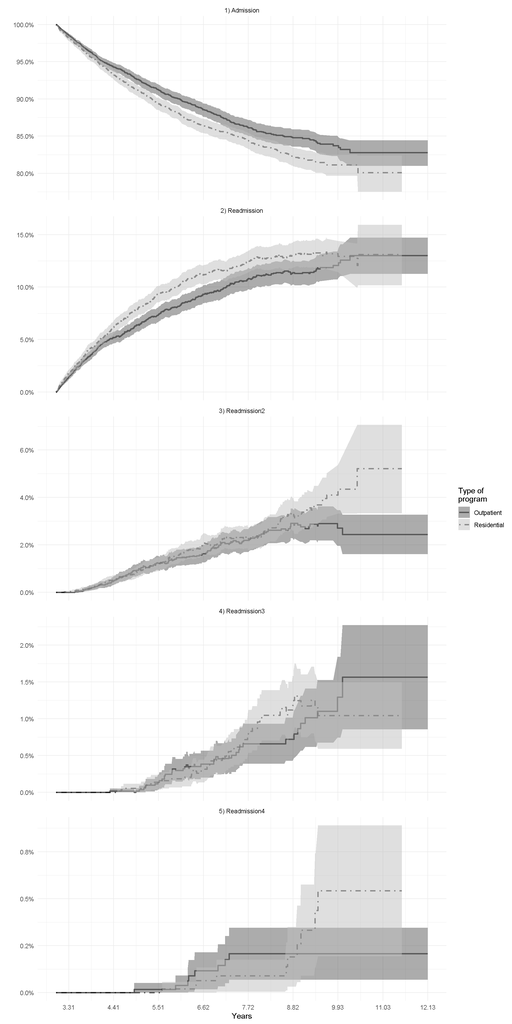

Figure 4a. State Occupancies, landmark Aalen-Johansen estimator (At 3 years, from State 1)

```r
#A data frame containing estimates and associated standard errors of the transition probabilities P(X(t)=k | X(s) in from) with s and from the arguments of the function.

#View(lmaj_df %>% dplyr::mutate_at(3:22,~round(.,2)) %>% dplyr::filter(time==90))
#View(lmaj_df %>% dplyr::mutate_at(3:22,~round(.,2)))

lmaj_plot<-
rbind(cbind(pr="res",lmaj_res_1_1095,transo=1),
      cbind(pr="out",lmaj_out_1_1095,transo=1)) %>%
  melt(id.vars=c("pr","transo","time")) %>%
  dplyr::rename("state_from"="transo") %>%
  dplyr::mutate(state_to=stri_sub(variable,-1,-1)) %>%
    dplyr::mutate(setting= dplyr::case_when(grepl("out",pr)~"Outpatient",
                                            grepl("res",pr)~"Residential",
                                            T~NA_character_)) %>%
      dplyr::mutate(measure= dplyr::case_when(grepl("se",variable)~"se",
                                            grepl("pstate",variable)~"Estimate",
                                            T~NA_character_)) %>%
  dplyr::select(-pr,-variable) %>%
  tidyr::pivot_wider(names_from=measure,values_from = value) %>%
  dplyr::mutate(lo_ci=pmax(0,1-(1-Estimate)* + exp(qnorm(0.975)*se/(1-Estimate)))) %>%
  dplyr::mutate(up_ci=1-(1-Estimate)* + exp(-qnorm(0.975)*se/(1-Estimate))) %>%
  dplyr::filter(state_from>0, state_to>0) %>%

  purrr::when(dplyr::group_by(.,time, state_from, state_to, setting) %>% summarise(n=n()) %>% dplyr::filter(n>1)%>% nrow()>0 ~ stop("There are cases with differences different than 0 days of a variable that should be equal"),
            ~.) %>%
  dplyr::mutate(state_from=factor(state_from),state_to=factor(state_to), setting=factor(setting)) %>%
  ggplot(aes(time, Estimate, linetype =setting))+
  geom_step(size=1, alpha=.65) +
  geom_ribbon(aes(ymin=lo_ci, ymax=up_ci, fill=setting), alpha=.5)+#, fill=setting
  facet_wrap(state_to~., ncol=1, scales="free_y",labeller = as_labeller(states_trans_lab)) + #
  scale_y_continuous(labels = scales::percent_format(accuracy = .1))+
  #facet_wrap(state~., ncol=1, scales="free_y") + #type_of_program
  scale_fill_manual(name= "Type of\nprogram",values=c("gray35","gray75"), labels=c("Outpatient","Residential"))+
  scale_linetype_manual(name= "Type of\nprogram",values=c(1,4), labels=c("Outpatient","Residential")) +
  scale_x_continuous(breaks=seq(0,max(c(msf0$Haz$time,msf1$Haz$time),na.rm=T),by=max(c(msf0$Haz$time,msf1$Haz$time),na.rm=T)/11),
                     label=round(seq(0,max(c(msf0$Haz$time,msf1$Haz$time),na.rm=T),by=max(c(msf0$Haz$time,msf1$Haz$time),na.rm=T)/11)/365.25,2))+
  xlab("Years") +
  ylab("") +
  theme_minimal()
lmaj_plot
```

```r
if(no_mostrar==1){
jpeg(paste0(gsub("SUD_CL/Matching_Process_APR_21.Rmd","",path),"_mult_state_ags/lmaj_st_occ_jun.jpg"), height=20, width= 10, res= 320, units = "in")
lmaj_plot
dev.off()
}
```

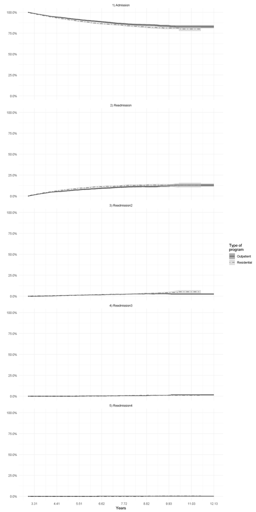

Figure 4b. State Occupancies, landmark Aalen-Johansen estimator (at s=3 years)

```r
#A data frame containing estimates and associated standard errors of the transition probabilities P(X(t)=k | X(s) in from) with s and from the arguments of the function.

#View(lmaj_df %>% dplyr::mutate_at(3:22,~round(.,2)) %>% dplyr::filter(time==90))
#View(lmaj_df %>% dplyr::mutate_at(3:22,~round(.,2)))

lmaj_plot2<-
rbind(cbind(pr="res",lmaj2_res_1_1095,transo=1),
      cbind(pr="out",lmaj2_out_1_1095,transo=1)) %>%
  melt(id.vars=c("pr","transo","time")) %>%
  dplyr::rename("state_from"="transo") %>%
  dplyr::mutate(state_to=stri_sub(variable,-1,-1)) %>%
    dplyr::mutate(setting= dplyr::case_when(grepl("out",pr)~"Outpatient",
                                            grepl("res",pr)~"Residential",
                                            T~NA_character_)) %>%
      dplyr::mutate(measure= dplyr::case_when(grepl("se",variable)~"se",
                                            grepl("pstate",variable)~"Estimate",
                                            T~NA_character_)) %>%
  dplyr::select(-pr,-variable) %>%
  tidyr::pivot_wider(names_from=measure,values_from = value) %>%
  dplyr::mutate(lo_ci=pmax(0,1-(1-Estimate)* + exp(qnorm(0.975)*se/(1-Estimate)))) %>%
  dplyr::mutate(up_ci=1-(1-Estimate)* + exp(-qnorm(0.975)*se/(1-Estimate))) %>%
  dplyr::filter(state_from>0, state_to>0) %>%

  purrr::when(dplyr::group_by(.,time, state_from, state_to, setting) %>% summarise(n=n()) %>% dplyr::filter(n>1)%>% nrow()>0 ~ stop("There are cases with differences different than 0 days of a variable that should be equal"),
            ~.) %>%
  dplyr::mutate(state_from=factor(state_from),state_to=factor(state_to), setting=factor(setting)) %>%
  ggplot(aes(time, Estimate, linetype =setting))+
  geom_step(size=1, alpha=.65) +
  geom_ribbon(aes(ymin=lo_ci, ymax=up_ci, fill=setting), alpha=.5)+#, fill=setting
  facet_wrap(state_to~., ncol=1, labeller = as_labeller(states_trans_lab)) + #scales="free_y",
  scale_y_continuous(labels = scales::percent_format(accuracy = .1))+
  #facet_wrap(state~., ncol=1, scales="free_y") + #type_of_program
  scale_fill_manual(name= "Type of\nprogram",values=c("gray35","gray75"), labels=c("Outpatient","Residential"))+
  scale_linetype_manual(name= "Type of\nprogram",values=c(1,4), labels=c("Outpatient","Residential")) +
  scale_x_continuous(breaks=seq(0,max(c(msf0$Haz$time,msf1$Haz$time),na.rm=T),by=max(c(msf0$Haz$time,msf1$Haz$time),na.rm=T)/11),
                     label=round(seq(0,max(c(msf0$Haz$time,msf1$Haz$time),na.rm=T),by=max(c(msf0$Haz$time,msf1$Haz$time),na.rm=T)/11)/365.25,2))+
  xlab("Years") +
  ylab("") +
  theme_minimal()
lmaj_plot2
```

```r
if(no_mostrar==1){
jpeg(paste0(gsub("SUD_CL/Matching_Process_APR_21.Rmd","",path),"_mult_state_ags/lmaj_st_occ_jun.jpg"), height=20, width= 10, res= 320, units = "in")
lmaj_plot2
dev.off()
}
```

```r
# Prob.occ5 <- data.frame(P=tmp.prob,
# lci=tmp.prob-qnorm(0.975)*c(tmp$se1,tmp$se2,tmp$se3),
# uci=tmp.prob+qnorm(0.975)*c(tmp$se1,tmp$se2,tmp$se3))

lmaj_ci_df<-
  rbind(cbind(pr="res",lmaj2_res_1_1095,transo=1),
  cbind(pr="out",lmaj2_out_1_1095,transo=1)) %>%
  rbind(cbind(pr="res",lmaj2_res_2_1095,transo=2),
  cbind(pr="out",lmaj2_out_2_1095,transo=2)) %>%
  rbind(cbind(pr="res",lmaj2_res_3_1095,transo=3),
  cbind(pr="out",lmaj2_out_3_1095,transo=3)) %>%
  rbind(cbind(pr="res",lmaj2_res_4_1095,transo=4),
  cbind(pr="out",lmaj2_out_4_1095,transo=4)) %>%
  dplyr::mutate(lo_pstate1=pmax(0,1-(1-pstate1)* + exp(qnorm(0.975)*se1/(1-pstate1)))) %>%
  dplyr::mutate(up_pstate1=1-(1-pstate1)* + exp(-qnorm(0.975)*se1/(1-pstate1))) %>%
  dplyr::mutate(lo_pstate2=pmax(0,1-(1-pstate2)* + exp(qnorm(0.975)*se2/(1-pstate2)))) %>%
  dplyr::mutate(up_pstate2=1-(1-pstate2)* + exp(-qnorm(0.975)*se2/(1-pstate2))) %>%
  dplyr::mutate(lo_pstate3=pmax(0,1-(1-pstate3)* + exp(qnorm(0.975)*se3/(1-pstate3)))) %>%
  dplyr::mutate(up_pstate3=1-(1-pstate3)* + exp(-qnorm(0.975)*se3/(1-pstate3))) %>%
  dplyr::mutate(lo_pstate4=pmax(0,1-(1-pstate4)* + exp(qnorm(0.975)*se4/(1-pstate4)))) %>%
  dplyr::mutate(up_pstate4=1-(1-pstate4)* + exp(-qnorm(0.975)*se4/(1-pstate4))) %>%
  dplyr::mutate(lo_pstate5=pmax(0,1-(1-pstate5)* + exp(qnorm(0.975)*se5/(1-pstate5)))) %>%
  dplyr::mutate(up_pstate5=1-(1-pstate5)* + exp(-qnorm(0.975)*se5/(1-pstate5))) %>%
  melt(id.vars=c("pr","transo","time")) %>%
  dplyr::rename("state_from"="transo") %>%
  dplyr::mutate(state_to=stri_sub(variable,-1,-1)) %>%
  dplyr::mutate(setting= dplyr::case_when(grepl("out",pr)~"Outpatient",
                                            grepl("res",pr)~"Residential",
                                            T~NA_character_)) %>%
  dplyr::mutate(measure= dplyr::case_when(grepl("se",variable)~"se",
                                          grepl("lo",variable)~"l95ci",
                                          grepl("up",variable)~"u95ci",
                                          grepl("pstate",variable)~"Estimate",
                                          T~NA_character_)) %>%
  dplyr::select(-pr,-variable) %>%
  purrr::when(dplyr::group_by(.,state_from, time, state_to, setting, measure)%>% summarise(n=n())%>% dplyr::filter(n>1)%>% nrow()>0 ~ stop("There are cases with differences different than 0 days of a variable that should be equal"),
            ~.) %>%
  tidyr::pivot_wider(names_from=measure,values_from = value) %>%
  dplyr::mutate(state_from=ifelse(state_from==0,5,state_from)) %>%
  dplyr::mutate(state_to=ifelse(state_to==0,5,state_to)) %>%
  #dplyr::filter(state_from>0, state_to>0) %>%
  purrr::when(dplyr::group_by(.,time, state_from, state_to, setting) %>% summarise(n=n()) %>% dplyr::filter(n>1)%>% nrow()>0 ~ stop("There are cases with differences different than 0 days of a variable that should be equal"),
            ~.) %>%
  dplyr::mutate(setting=factor(setting))
# Prob.occ5 <- data.frame(P=tmp.prob,
# lci=tmp.prob-qnorm(0.975)*c(tmp$se1,tmp$se2,tmp$se3),
# uci=tmp.prob+qnorm(0.975)*c(tmp$se1,tmp$se2,tmp$se3))

lmaj_ci_df2<-
  rbind(cbind(pr="res",lmaj2_res_1,transo=1),
  cbind(pr="out",lmaj2_out_1,transo=1)) %>%
  rbind(cbind(pr="res",lmaj2_res_2,transo=2),
  cbind(pr="out",lmaj2_out_2,transo=2)) %>%
  rbind(cbind(pr="res",lmaj2_res_3,transo=3),
  cbind(pr="out",lmaj2_out_3,transo=3)) %>%
  dplyr::mutate(lo_pstate1=pmax(0,1-(1-pstate1)* + exp(qnorm(0.975)*se1/(1-pstate1)))) %>%
  dplyr::mutate(up_pstate1=1-(1-pstate1)* + exp(-qnorm(0.975)*se1/(1-pstate1))) %>%
  dplyr::mutate(lo_pstate2=pmax(0,1-(1-pstate2)* + exp(qnorm(0.975)*se2/(1-pstate2)))) %>%
  dplyr::mutate(up_pstate2=1-(1-pstate2)* + exp(-qnorm(0.975)*se2/(1-pstate2))) %>%
  dplyr::mutate(lo_pstate3=pmax(0,1-(1-pstate3)* + exp(qnorm(0.975)*se3/(1-pstate3)))) %>%
  dplyr::mutate(up_pstate3=1-(1-pstate3)* + exp(-qnorm(0.975)*se3/(1-pstate3))) %>%
  dplyr::mutate(lo_pstate4=pmax(0,1-(1-pstate4)* + exp(qnorm(0.975)*se4/(1-pstate4)))) %>%
  dplyr::mutate(up_pstate4=1-(1-pstate4)* + exp(-qnorm(0.975)*se4/(1-pstate4))) %>%
  dplyr::mutate(lo_pstate5=pmax(0,1-(1-pstate5)* + exp(qnorm(0.975)*se5/(1-pstate5)))) %>%
  dplyr::mutate(up_pstate5=1-(1-pstate5)* + exp(-qnorm(0.975)*se5/(1-pstate5))) %>%
  melt(id.vars=c("pr","transo","time")) %>%
  dplyr::rename("state_from"="transo") %>%
  dplyr::mutate(state_to=stri_sub(variable,-1,-1)) %>%
  dplyr::mutate(setting= dplyr::case_when(grepl("out",pr)~"Outpatient",
                                            grepl("res",pr)~"Residential",
                                            T~NA_character_)) %>%
  dplyr::mutate(measure= dplyr::case_when(grepl("se",variable)~"se",
                                          grepl("lo",variable)~"l95ci",
                                          grepl("up",variable)~"u95ci",
                                          grepl("pstate",variable)~"Estimate",
                                          T~NA_character_)) %>%
  dplyr::select(-pr,-variable) %>%
  purrr::when(dplyr::group_by(.,state_from, time, state_to, setting, measure)%>% summarise(n=n())%>% dplyr::filter(n>1)%>% nrow()>0 ~ stop("There are cases with differences different than 0 days of a variable that should be equal"),
            ~.) %>%
  tidyr::pivot_wider(names_from=measure,values_from = value) %>%
  #dplyr::filter(state_from>0, state_to>0) %>%
  purrr::when(dplyr::group_by(.,time, state_from, state_to, setting) %>% summarise(n=n()) %>% dplyr::filter(n>1)%>% nrow()>0 ~ stop("There are cases with differences different than 0 days of a variable that should be equal"),
            ~.) %>%
  dplyr::mutate(setting=factor(setting))
lmaj_ci_df2 %>%
    dplyr::select(time, state_from, state_to, setting, Estimate, l95ci, u95ci) %>%
    dplyr::arrange(state_from,state_to,setting,time) %>%
    dplyr::mutate(state_to=as.numeric(state_to)) %>%
    dplyr::filter(time %in% c(90, 365, 1095, 1826,1827)) %>%
    dplyr::mutate(time=factor(time, levels=c(90, 365, 1095, 1826,1827),
                              labels=c("~90days/3 months", "~1 year", "~3 years", "~5 years","~5 years"),ordered=T)) %>%
    dplyr::mutate(comb=paste0(state_from,"_",state_to)) %>%
    dplyr::filter(comb %in% c("1_2","1_2","1_3","1_4","1_5")) %>%
    dplyr::left_join(cbind.data.frame(states_trans_lab,st=1:5), by=c("state_from"="st")) %>%
    dplyr::left_join(cbind.data.frame(states_trans_lab,st=1:5), by=c("state_to"="st")) %>%
    dplyr::select(-comb) %>%
    dplyr::rename("state_from_lab"="states_trans_lab.x","state_to_lab"="states_trans_lab.y") %>%
    dplyr::mutate(est_ci=paste0(sprintf("%1.3f",Estimate)," [",sprintf("%1.3f",abs(l95ci)),"-",sprintf("%1.3f",abs(u95ci)),"]")) %>%
    dplyr::arrange(time, state_from,state_to) %>%
    dplyr::select(time, setting, state_from_lab, state_to_lab, est_ci) %>%
    tidyr::pivot_wider(names_from=setting,values_from = est_ci) %>%
    dplyr::select(-time) %>%
    #2021-04-27: drop from/actual state, readmission
    knitr::kable(format = "html", format.args = list(decimal.mark = ".", big.mark = ","),
               caption = paste0("Table 1. Estimated transition probabilities, Five-states model (From state=1, at s=90 days)"),
                 col.names = c("State from","State to","Outpatient","Residential"),
                 align =rep('l', 2),rep('c', 2)) %>%
    kableExtra::kable_styling(bootstrap_options = c("striped", "hover"),font_size = 13) %>%
    kableExtra::add_footnote("Note. We removed Readmission because it was an absorbing state", notation="none") %>%
    #kableExtra::add_header_above(c(" ", "Women-specific: Transition to" = 4,"General Population: Transition to" = 4)) %>%
    kableExtra::pack_rows("At 90 days", 1, 4) %>%
    kableExtra::pack_rows("At ~1 year", 5, 8) %>%
    kableExtra::pack_rows("At ~3 years", 9, 12) %>%
    kableExtra::pack_rows("At ~5 years", 13, 16) %>%
    kableExtra::scroll_box(width = "100%", height = "375px")
```

Table 1. Estimated transition probabilities, Five-states model (From state=1, at s=90 days)

State from

State to

Outpatient

Residential

**At 90 days**

1. Admission
2. Readmission

0.000 [0.000-0.000]

0.000 [0.000-0.000]

1. Admission
3. Readmission2

0.000 [0.000-0.000]

0.000 [0.000-0.000]

1. Admission
4. Readmission3

0.000 [0.000-0.000]

0.000 [0.000-0.000]

1. Admission
5. Readmission4

0.000 [0.000-0.000]

0.000 [0.000-0.000]

**At ~1 year**

1. Admission
2. Readmission

0.061 [0.057-0.066]

0.104 [0.098-0.110]

1. Admission
3. Readmission2

0.002 [0.001-0.003]

0.005 [0.003-0.006]

1. Admission
4. Readmission3

0.000 [0.000-0.000]

0.000 [0.000-0.001]

1. Admission
5. Readmission4

0.000 [0.000-0.000]

0.000 [0.000-0.000]

**At ~3 years**

1. Admission
2. Readmission

0.151 [0.144-0.158]

0.213 [0.205-0.221]

1. Admission
3. Readmission2

0.031 [0.028-0.035]

0.048 [0.043-0.052]

1. Admission
4. Readmission3

0.005 [0.003-0.006]

0.009 [0.007-0.010]

1. Admission
5. Readmission4

0.001 [0.000-0.001]

0.002 [0.001-0.002]

**At ~5 years**

1. Admission
2. Readmission

0.177 [0.169-0.186]

0.233 [0.224-0.241]

1. Admission
3. Readmission2

0.054 [0.049-0.059]

0.077 [0.071-0.082]

1. Admission
4. Readmission3

0.012 [0.010-0.015]

0.020 [0.017-0.023]

1. Admission
5. Readmission4

0.004 [0.002-0.005]

0.007 [0.005-0.009]

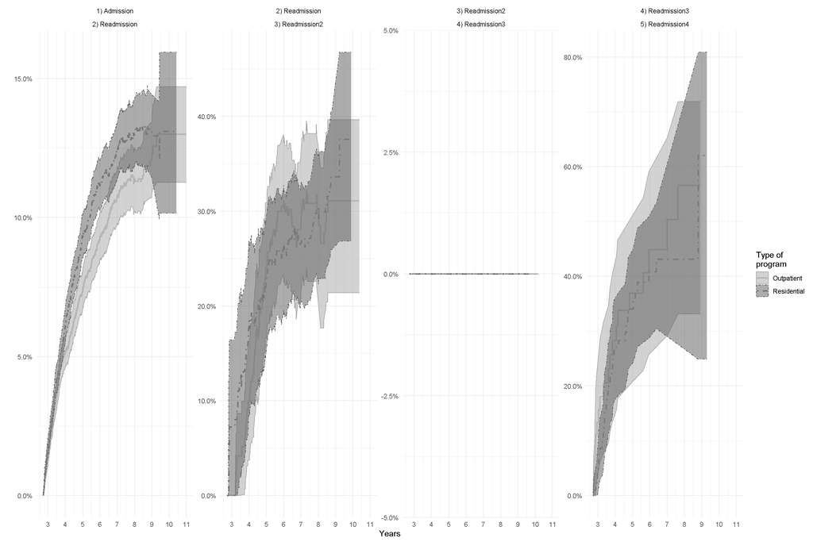

Figure 4a. State Occupancies & 95% CIs, landmark Aalen-Johansen estimator (at 3 years)

```r
lmaj_ci_df_plot<-
lmaj_ci_df %>%
  dplyr::mutate(l95ci=dplyr::case_when(se<.1 & Estimate==1~1,T~l95ci),
                u95ci=dplyr::case_when(se<.1 & Estimate==1~1,T~u95ci)) %>%
      dplyr::mutate(comb=paste0(state_from,"_",state_to)) %>%
    dplyr::filter(comb %in% c("1_2","2_3","3_4","4_5")) %>%
 # dplyr::filter(state_from==1) %>%
  ggplot(aes(time, Estimate, color= setting, linetype =setting, fill=setting))+
  geom_step(size=1, alpha=.65) +
  geom_ribbon(aes(ymin=l95ci, ymax=u95ci, fill=setting), alpha=.5)+
  facet_wrap(state_from~state_to, ncol=5, scales="free_y", labeller = as_labeller(states_trans_lab)) + #
  scale_y_continuous(labels = scales::percent_format(accuracy = .1))+
  #facet_wrap(state~., ncol=5, scales="free_y") + #type_of_program
  scale_color_manual(name= "Type of\nprogram",values=c("gray65","gray35"), labels=c("Outpatient","Residential")) +
  scale_fill_manual(name= "Type of\nprogram",values=c("gray65","gray35"), labels=c("Outpatient","Residential")) +
  scale_linetype_manual(name= "Type of\nprogram",values=c(1,4), labels=c("Outpatient","Residential")) +
  scale_x_continuous(breaks=seq(0,max(c(msf0$Haz$time,msf1$Haz$time),na.rm=T),by=max(c(msf0$Haz$time,msf1$Haz$time),na.rm=T)/11),
                     label=0:11)+
  xlab("Years") +
  ylab("") +
  theme_minimal()

lmaj_ci_df_plot
```

```r
if(no_mostrar==1){
jpeg(paste0(gsub("SUD_CL/Matching_Process_JUN_21.Rmd","",path),"_mult_state_ags/probtrans_states_trans_jun2.jpg"), height=10, width= 15, res= 320, units = "in")
lmaj_ci_df_plot
dev.off()
}
```

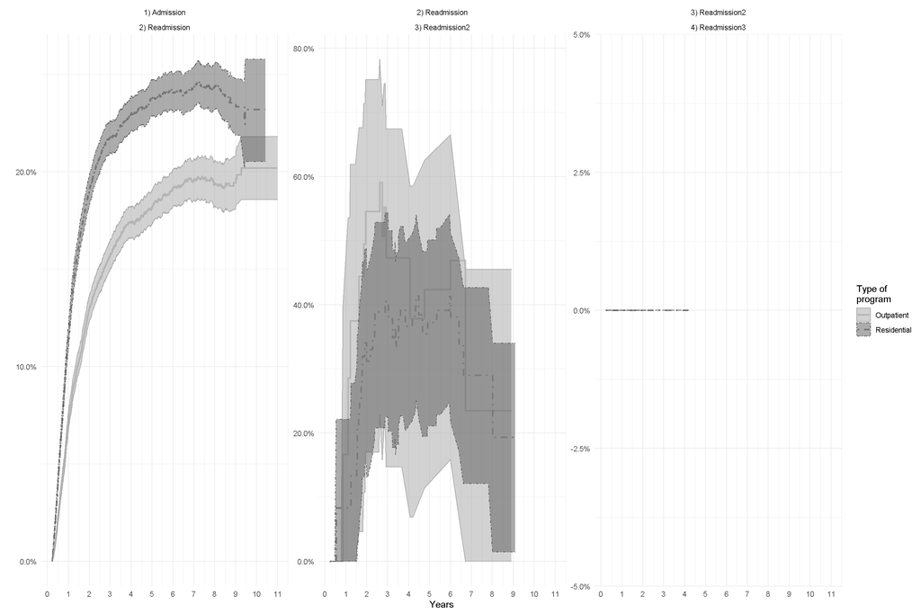

Figure 4b. State Occupancies & 95% CIs, landmark Aalen-Johansen estimator (At 90 days)

```r
lmaj_ci_df_plot2<-
  lmaj_ci_df2 %>%
    dplyr::mutate(l95ci=dplyr::case_when(se<.1 & Estimate==1~1,T~l95ci),
                u95ci=dplyr::case_when(se<.1 & Estimate==1~1,T~u95ci)) %>%
        dplyr::mutate(comb=paste0(state_from,"_",state_to)) %>%
    dplyr::filter(comb %in% c("1_2","2_3","3_4","4_5")) %>%
    ggplot(aes(time, Estimate, color= setting, linetype =setting, fill=setting))+
    geom_step(size=1, alpha=.65) +
    geom_ribbon(aes(ymin=l95ci, ymax=u95ci, fill=setting), alpha=.5)+
    facet_wrap(state_from~state_to, ncol=5, scales="free_y", labeller = as_labeller(states_trans_lab)) + #
    scale_y_continuous(labels = scales::percent_format(accuracy = .1))+
    #facet_wrap(state~., ncol=1, scales="free_y") + #type_of_program
    scale_color_manual(name= "Type of\nprogram",values=c("gray65","gray35"), labels=c("Outpatient","Residential")) +
    scale_fill_manual(name= "Type of\nprogram",values=c("gray65","gray35"), labels=c("Outpatient","Residential")) +
    scale_linetype_manual(name= "Type of\nprogram",values=c(1,4), labels=c("Outpatient","Residential")) +
    scale_x_continuous(breaks=seq(0,max(c(msf0$Haz$time,msf1$Haz$time),na.rm=T),by=max(c(msf0$Haz$time,msf1$Haz$time),na.rm=T)/11),
                       label=0:11)+
    xlab("Years") +
    ylab("") +
    theme_minimal()

lmaj_ci_df_plot2
```

```r
#jpeg(paste0(jpg_path,"_mult_state_ags/Cum_haz_markov_set_jun2.jpg"), height=14, width= 12, res= 320, units = "in")

if(no_mostrar==1){
jpeg(paste0(jpg_path,"_mult_state_ags/probtrans_states_trans_jun2.jpg"), height=10, width= 15, res= 320, units = "in")
lmaj_ci_df_plot2
dev.off()
}
```

## Transition Probabilities, Markov

```r
#, fig.height=13, fig.width=10, fig.cap="Figure 12a. Aalen-Johansen estimator with confidence intervals", fig.align="center"
#n_iter=1000

set.seed(1234)
pt_markov_0 <- probtrans(msfx0,
                predt=0,#his is either the time at which the prediction is made (if direction= "forward")
                direction="forward",#One of "forward" (default) or "fixedhorizon", indicating whether prediction is forward or for a fixed horizon
                method="aalen",# character string specifying the type of variances to be computed (so only needed if either variance or covariance is TRUE).
                variance=T,#Logical value indicating whether standard errors are to be calculated (default is TRUE)
                covariance=F)#Logical value indicating whether covariances of transition probabilities for different states are to be calculated (default is FALSE)

pt_markov_1 <- probtrans(msfx1,
                predt=0,#his is either the time at which the prediction is made (if direction= "forward")
                direction="forward",#One of "forward" (default) or "fixedhorizon", indicating whether prediction is forward or for a fixed horizon
                method="aalen",# character string specifying the type of variances to be computed (so only needed if either variance or covariance is TRUE).
                variance=T,#Logical value indicating whether standard errors are to be calculated (default is TRUE)
                covariance=F)#Logical value indicating whether covariances of transition probabilities for different states are to be calculated (default is FALSE)
```

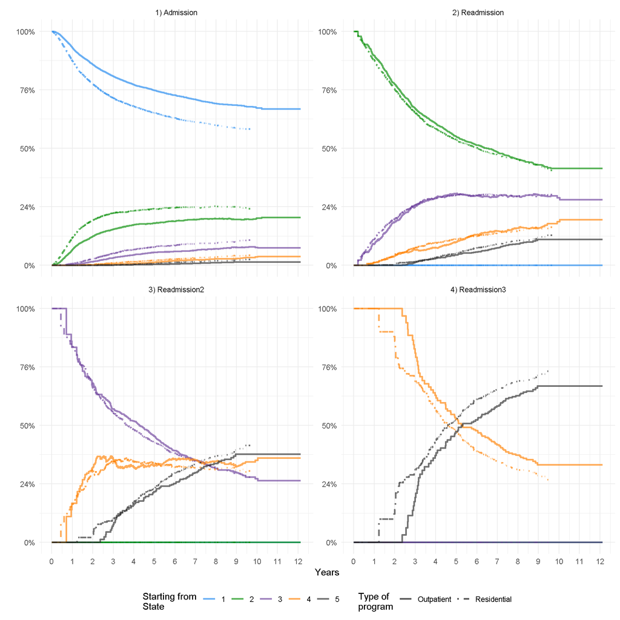

Figure 5. Estimate of State Occupancies at Baseline, Five-states model (Markov)

```r
#states_trans_lab<-paste0(1:10,") ",states_trans)
#attr(states_trans_lab,"names")<-1:10

ab_pmatrix_probtrans<-
  pt_markov_0[[1]] %>%
  dplyr::left_join(pt_markov_1[[1]], by="time", suffix=c("",".w_covs.res.s01")) %>%
  dplyr::left_join(pt_markov_0[[2]], by="time", suffix=c("",".w_covs.out.s02")) %>%
  dplyr::left_join(pt_markov_1[[2]], by="time", suffix=c("",".w_covs.res.s02")) %>%
  dplyr::left_join(pt_markov_0[[3]], by="time", suffix=c("",".w_covs.out.s03")) %>%
  dplyr::left_join(pt_markov_1[[3]], by="time", suffix=c("",".w_covs.res.s03")) %>%
  dplyr::left_join(pt_markov_0[[4]], by="time", suffix=c("",".w_covs.out.s04")) %>%
  dplyr::left_join(pt_markov_1[[4]], by="time", suffix=c("",".w_covs.res.s04")) %>%
    dplyr::select(-starts_with("se")) %>%
  dplyr::rename("pstate1.w_covs.out.s1"="pstate1",
                "pstate2.w_covs.out.s1"="pstate2",
                "pstate3.w_covs.out.s1"="pstate3",
                "pstate4.w_covs.out.s1"="pstate4",
                "pstate5.w_covs.out.s1"="pstate5") %>%
  #pstate1–pstate3 are close to the first rows of the matrices returned by pmatrix.fs
  reshape2::melt(id.vars="time") %>% #janitor::tabyl(variable)
  dplyr::mutate(start=stringi::stri_sub(variable,-1,-1)) %>%
  dplyr::mutate(state_to=stringi::stri_match_first_regex(variable, "(.*?)\\.")[,2]) %>%
  dplyr::mutate(state_to=gsub("pstate", "", state_to), state_to=as.numeric(state_to)) %>%
  dplyr::mutate(setting= dplyr::case_when(grepl(".out",variable)~"Outpatient",
                                               grepl(".res",variable)~"Residential",
                                               T~NA_character_))

fig_ab_pmatrix_probtrans<-
  #janitor::tabyl(start)
  ggplot(ab_pmatrix_probtrans, aes(time, value, color= factor(state_to), linetype =setting))+
    geom_step(size=1, alpha=.65) +
    scale_y_continuous(labels = scales::percent_format(accuracy = 2))+
    facet_wrap(start~., ncol=2, scales="free_y", labeller = as_labeller(states_trans_lab)) +
    #facet_wrap(state~., ncol=1, scales="free_y") + #type_of_program
    scale_color_manual(name = "Starting from\nState", values=c26, labels= as.character(c(1:10))) + # "#A65100" #"Cox",
    scale_linetype_manual(name= "Type of\nprogram",values=c(1,4), labels=c("Outpatient","Residential")) +
   scale_x_continuous(breaks=seq(0,max(c(msf0$Haz$time,msf1$Haz$time),na.rm=T),by=365.25),
                     label=seq(0,round(max(c(msf0$Haz$time,msf1$Haz$time),na.rm=T)/365.25),by=1))+
    xlab("Years") +
    ylab("") +
    theme_minimal()+
    #theme(legend.position=c(.7,.2))+
    theme(legend.position="bottom")+
  guides(color=guide_legend(ncol=5))

fig_ab_pmatrix_probtrans
```

```r
if(no_mostrar==1){
jpeg(paste0(jpg_path,"_mult_state_ags/probtrans_states_jun.jpg"), height=10, width= 10, res= 320, units = "in")
fig_ab_pmatrix_probtrans
dev.off()
}
```

```r
myplots<- vector("list")

for (i in rep(1:5,2)){
  myplots[[paste0("pt_0_",i)]]<- plot(pt_markov_0, from= i,type="single",use.ggplot= TRUE)
  myplots[[paste0("pt_1_",i)]]<- plot(pt_markov_1, from= i,type="single",use.ggplot= TRUE)
}
```

```
## Error in from$toXYZ(color, from.ref.white): ncol(Lab) == 3L || length(Lab) == 3 is not TRUE
```

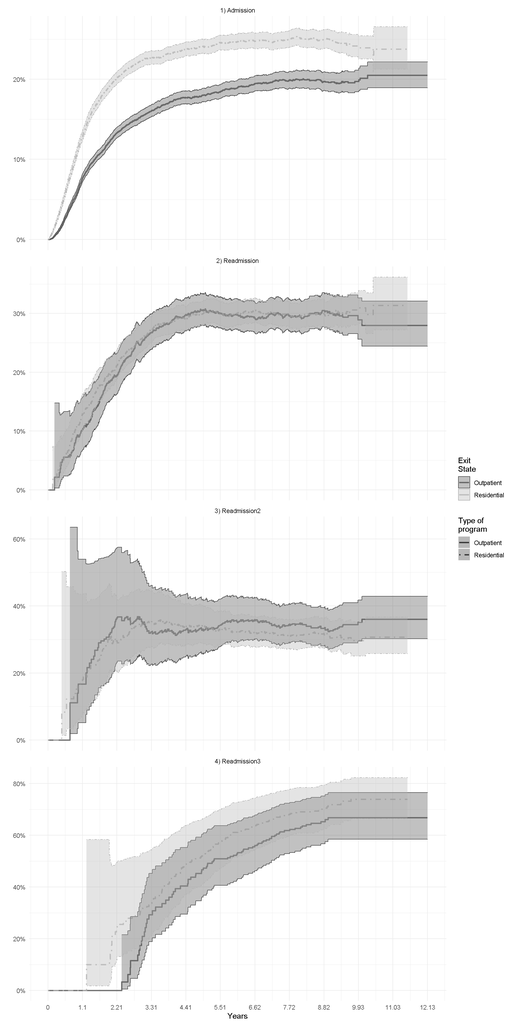

Figure 6. Estimate of Transition Probabilities to the following state, Five-states model (Markov)

```r
probtrans_df<-
rbind(cbind(subset(myplots$pt_0_1$data,state_num %in% c(2))[,c("time","state","prob","CI_low","CI_upp")],res=0, st=1),
      cbind(subset(myplots$pt_1_1$data,state_num %in% c(2))[,c("time","state","prob","CI_low","CI_upp")],res=1, st=1),
      cbind(subset(myplots$pt_0_2$data,state_num %in% c(3))[,c("time","state","prob","CI_low","CI_upp")],res=0, st=2),
      cbind(subset(myplots$pt_1_2$data,state_num %in% c(3))[,c("time","state","prob","CI_low","CI_upp")],res=1, st=2),
      cbind(subset(myplots$pt_0_3$data,state_num %in% c(4))[,c("time","state","prob","CI_low","CI_upp")],res=0, st=3),
      cbind(subset(myplots$pt_1_3$data,state_num %in% c(4))[,c("time","state","prob","CI_low","CI_upp")],res=1, st=3),
      cbind(subset(myplots$pt_0_4$data,state_num %in% c(5))[,c("time","state","prob","CI_low","CI_upp")],res=0, st=4),
      cbind(subset(myplots$pt_1_4$data,state_num %in% c(5))[,c("time","state","prob","CI_low","CI_upp")],res=1, st=4)
)

probtrans_df_plot<-
probtrans_df %>%
  dplyr::mutate(res=factor(res), state=factor(state)) %>%
 ggplot()+
    geom_step(aes(time, prob, color= res, fill=res, linetype =res),size=1, alpha=.75) +
    geom_ribbon(aes(x=time, fill=res, color= res, linetype =res, ymin=CI_low, ymax=CI_upp), alpha=.35)+
    scale_y_continuous(labels = scales::percent_format(accuracy = 2))+
    facet_wrap(st~., ncol=1, scales="free_y", labeller = as_labeller(states_trans_lab)) +
    #facet_wrap(state~., ncol=1, scales="free_y") + #type_of_program
    scale_color_manual(name = "Exit\nState", values=c("gray30","gray70"), labels=c("Outpatient","Residential")) +
    scale_fill_manual(name = "Exit\nState", values=c("gray30","gray70"), labels=c("Outpatient","Residential")) +
    scale_linetype_manual(name= "Type of\nprogram",values=c(1,4), labels=c("Outpatient","Residential")) +
    scale_x_continuous(breaks=seq(0,max(c(msf0$Haz$time,msf1$Haz$time),na.rm=T),by=max(c(msf0$Haz$time,msf1$Haz$time),na.rm=T)/11),
                       label=round(seq(0,max(c(msf0$Haz$time,msf1$Haz$time),na.rm=T),by=max(c(msf0$Haz$time,msf1$Haz$time),na.rm=T)/11)/365.25,2))+
    xlab("Years") +
    ylab("") +
    theme_minimal()
probtrans_df_plot
```

```r
if(no_mostrar==1){
jpeg(paste0(gsub("SUD_CL/Matching_Process_APR_21.Rmd","",path),"_mult_state_ags/probtrans_states_trans_jun.jpg"), height=20, width= 10, res= 320, units = "in")
probtrans_df_plot
dev.off()
}
```

## Clustered multistate

```r
## Function that calculates the working independence Aalen-Johansen estimator
## of the population-averaged transition probabilities. Standard errors and
## and 95% confidence intervals and bands are also calculated.
## Auxiliary function to calculate the landmark version
## of the working independence Aalen-Johansen estimator.
## This is a modification of the LMAJ function in the
## R package mstate.

LMAJ2 <- function (msdata, tmat, id, s, h, j, weighted){
  if (is.null(tmat))
    stop("msdata object should have a \"trans\" attribute")
  K <- nrow(tmat)
  if (any(is.na(match(h, 1:K))))
    stop("h should be subset of 1:K with K number of states")
  attr(msdata, "trans") <- tmat
  xss <- xsect(msdata, s)
  infrom <- xss[xss$state %in% h,id]
  msdatas <- cutLMms(msdata, LM = s)
  msdatasfrom <- msdatas[msdatas[,id] %in% infrom, ]
  c0 <- coxph(Surv(Tstart, Tstop, status) ~ strata(trans),
              data = msdatasfrom)
  A0 <- msfit(c0, trans = tmat, variance=FALSE)
  if(weighted==TRUE){
    c0 <- coxph(Surv(Tstart, Tstop, status) ~ strata(trans),
                weights=(1/clust.size), data = msdatasfrom)
    A.wt <- basehaz(c0, centered=FALSE)
    A.wt$strata <- as.numeric(A.wt$strata)
    for(trn in sort(unique(A.wt$strata))){
      fun <- stepfun(A.wt[A.wt$strata==trn,"time"],
                     c(0,A.wt[A.wt$strata==trn,"hazard"]))
      A0$Haz[A0$Haz$trans==trn,"Haz"] <- fun(A0$Haz[A0$Haz$trans==trn,"time"])
    }
  }
  pt0 <- probtrans(A0, predt = s, variance=FALSE)[[h]][,c("time",
                                                          paste("pstate", j, sep=""))]
  return(pt0)
}

patp <- function(data, tmat, cid, id, h, j, s=0, weighted=FALSE,
                 LMAJ=FALSE, B=100, cband=FALSE){
  check.ic <- aggregate(data[,cid], by=list(data[,id]),
                        FUN=sd, na.rm=TRUE)$x
  check.ic <- check.ic[!is.na(check.ic)]
  if(length(check.ic)>0){
    if(max(check.ic)>0){
      stop("Same unit(s) in more than 1 cluster (violation of the independent clusters assumption)")
    }
  }

  if(B<=0 & cband==TRUE){
    stop("Condidence bands cannot be caclulated based on <=0 bootstrap samples")
  } else if (B<1000 & cband==TRUE){
    warning("It is recommended to use at least 1000 bootstrap samples for confidence band calculation")
  }
  if(LMAJ==FALSE){
    c0 <- coxph(Surv(Tstart, Tstop, status) ~ strata(trans), data=data,
                method = "breslow")

    A0 <- msfit(object = c0, trans = tmat, variance=FALSE)
    if(weighted==TRUE){
      ## msfit does not currently support weights and thus
      ## the weighted by cluster size cumulative transition
      ## intensities need to be manually inserted into A0
      M0 <- aggregate(rep(1,times=nrow(data)),
                      by = list( data[,cid], data[,id]),
                      FUN = mean)

      M <- aggregate(M0$x,
                     by = list( M0$Group.1),
                     FUN = sum)
      colnames(M) <- c(cid, "clust.size")
      data <- merge(data, M, by=cid)
      data <- data[order(data[,cid],data[,id]),]
      class(data) <- c("msdata", "data.frame")

      c0 <- coxph(Surv(Tstart, Tstop, status) ~ strata(trans),
                  weights=(1/clust.size), data=data,
                  method = "breslow")
      A.wt <- basehaz(c0, centered=FALSE)
      A.wt$strata <- as.numeric(A.wt$strata)
      for(trn in sort(unique(A.wt$strata))){
        fun <- stepfun(A.wt[A.wt$strata==trn,"time"],
                       c(0,A.wt[A.wt$strata==trn,"hazard"]))
        A0$Haz[A0$Haz$trans==trn,"Haz"] <- fun(A0$Haz[A0$Haz$trans==trn,"time"])
      }
    }
    P0 <- probtrans(A0, predt = s,
                    variance=FALSE)[[h]][,c("time",
                                            paste("pstate", j, sep=""))]
  } else {
    if(weighted==TRUE){
      M0 <- aggregate(rep(1,times=nrow(data)),
                      by = list( data[,cid], data[,id]),
                      FUN = mean)

      M <- aggregate(M0$x,
                     by = list( M0$Group.1),
                     FUN = sum)
      colnames(M) <- c(cid, "clust.size")
      data <- merge(data, M, by=cid)
      data <- data[order(data[,cid],data[,id]),]
      class(data) <- c("msdata", "data.frame")
    }
    P0 <- LMAJ2(msdata=data, tmat=tmat, id=id, s=s, h=h, j=j, weighted=weighted)
  }

  colnames(P0) <- c("time", paste("P", h, j, sep=""))
  if(B==0){
    return(P0)
  } else {
    n <- length(unique(data[,cid]))
    boot <- msboot(patp_b, data=data,
                   id=cid, B=B, verbose=0,
                   tmat=tmat, id2=id, h=h, j=j, s=s, times=P0$time,
                   wiaj_hat=P0[,paste("P", h, j, sep="")],
                   n=n, weighted=weighted, LMAJ=LMAJ)
    sigma <- apply(boot, 1, sd)
    se <- sigma/sqrt(n)

    ## cloglog transformation
    ll <- exp(-exp(log(-log(P0[,paste("P", h, j, sep="")]))-qnorm(0.975)*se/
                     (P0[,paste("P", h, j, sep="")]*
                        log(P0[,paste("P", h, j, sep="")]))))
    ul <- exp(-exp(log(-log(P0[,paste("P", h, j, sep="")]))+qnorm(0.975)*se/
                     (P0[,paste("P", h, j, sep="")]*
                        log(P0[,paste("P", h, j, sep="")]))))

    res <- cbind(P0, se, ll, ul)

    if(cband==TRUE){
      q_t <- 1/(1+sigma^2)

      jump.times <- P0$time[diff(c(P0[1,paste("P", h, j, sep="")],
                                   P0[,paste("P", h, j, sep="")]), lag=1)!=0]
      quant <- quantile(jump.times, probs=c(.05,.95))
      range <- (P0$time>=quant[1] & P0$time<=quant[2] &
                  P0[,paste("P", h, j, sep="")]>0)

      B_t <- q_t[range]*boot[range,]/(log(P0[range, paste("P", h, j, sep="")])*
                                        P0[range, paste("P", h, j, sep="")])
      B_t <- abs(B_t)
      c_a <- apply(B_t, 2, max)
      c_a <- quantile(c_a, probs=0.95)

      ## cloglog transformation
      ll.band <- exp(-exp(log(-log(P0[,paste("P", h, j, sep="")]))+c_a/(sqrt(n)*q_t)))
      ll.band[!range] <- NA
      ul.band <- exp(-exp(log(-log(P0[,paste("P", h, j, sep="")]))-c_a/(sqrt(n)*q_t)))
      ul.band[!range] <- NA
```

```r
      res <- cbind(res, ll.band, ul.band)
    }
    return(res)
  }
}

patp_b <- function(data, tmat, id2, h, j, s, times, wiaj_hat, n, weighted, LMAJ){
  if(LMAJ==FALSE){
    c0 <- coxph(Surv(Tstart, Tstop, status) ~ strata(trans), data=data,
                method = "breslow")

    A0 <- msfit(object = c0, trans = tmat, variance=FALSE)
    if(weighted==TRUE){
      c0 <- coxph(Surv(Tstart, Tstop, status) ~ strata(trans),
                  weights=(1/clust.size), data=data,
                  method = "breslow")
      A.wt <- basehaz(c0, centered=FALSE)
      A.wt$strata <- as.numeric(A.wt$strata)
      for(trn in sort(unique(A.wt$strata))){
        fun <- stepfun(A.wt[A.wt$strata==trn,"time"],
                       c(0,A.wt[A.wt$strata==trn,"hazard"]))
        A0$Haz[A0$Haz$trans==trn,"Haz"] <- fun(A0$Haz[A0$Haz$trans==trn,"time"])
      }
    }

    P0 <- probtrans(A0, predt = s,
                    variance=FALSE)[[h]][,c("time",
                                            paste("pstate", j, sep=""))]
  } else {
    P0 <- LMAJ2(msdata=data, tmat=tmat, id=id2, s=s, h=h, j=j, weighted=weighted)
  }

  P0_t <-stepfun(P0$time, c(P0[1,paste("pstate", j, sep="")],
                            P0[,paste("pstate", j, sep="")]))

  return(sqrt(n)*(P0_t(times)-wiaj_hat))
}

patp_test <- function(data, tmat, cid, id, group, h, j, s=0,
                      weighted=FALSE, LMAJ=FALSE, B=1000){
  check.ic <- aggregate(data[,cid], by=list(data[,id]),
                        FUN=sd, na.rm=TRUE)$x
  check.ic <- check.ic[!is.na(check.ic)]
  if(length(check.ic)>0){
    if(max(check.ic)>0){
      stop("Same unit(s) in more than 1 cluster (violation of the independent clusters assumption)")
    }
  }

  if(B<=0){
    stop("Tests cannot be performed based on <=0 bootstrap samples")
  } else if (B<1000){
    warning("It is recommended to use at least 1000 bootstrap samples for two-sample testing")
  }
  n <- length(unique(data[,cid]))
  groups <- unique(data[,group])
  groups <- sort(groups[!is.na(groups)])
  if(length(groups)!=2){
    stop("Number of groups != 2")
  }

  if(weighted==TRUE){
    M0 <- aggregate(rep(1,times=nrow(data)),
                    by = list(data[,cid],
                              data[,group],
                              data[,id]),
                    FUN = mean)

    M <- aggregate(M0$x,
                   by = list(M0$Group.1, M0$Group.2),
                   FUN = sum)
    colnames(M) <- c(cid, group, "clust.size")
    data <- merge(data, M, by=c(cid,group))
    data <- data[order(data[,cid],data[,id]),]
    class(data) <- c("msdata", "data.frame")
  }

  Pt <- list()
  tms <- list()
  for(g in groups){
    if(LMAJ==FALSE){
      c0 <- coxph(Surv(Tstart, Tstop, status) ~ strata(trans),
                  data=data[data[,group]==g,], method = "breslow")

      A0 <- msfit(object = c0, trans = tmat, variance=FALSE)
      if(weighted==TRUE){
        c0 <- coxph(Surv(Tstart, Tstop, status) ~ strata(trans),
                    weights=(1/clust.size), data=data[data[,group]==g,],
                    method = "breslow")
        A.wt <- basehaz(c0, centered=FALSE)
        A.wt$strata <- as.numeric(A.wt$strata)
        for(trn in sort(unique(A.wt$strata))){
          fun <- stepfun(A.wt[A.wt$strata==trn,"time"],
                         c(0,A.wt[A.wt$strata==trn,"hazard"]))
          A0$Haz[A0$Haz$trans==trn,"Haz"] <- fun(A0$Haz[A0$Haz$trans==trn,"time"])
        }
      }

      P0 <- probtrans(A0, predt = s, variance=FALSE)[[h]][,c("time",
                                                             paste("pstate", j, sep=""))]
    } else {
      P0 <- LMAJ2(msdata=data[data[,group]==g,], tmat=tmat,
                  id=id, s=s, h=h, j=j, weighted=weighted)
    }
    if(length(Pt)==0){
      Pt[[1]] <- stepfun(P0$time, c(P0[1,paste("pstate", j, sep="")],
                                    P0[,paste("pstate", j, sep="")]))
      tms[[1]] <- P0$time[diff(c(P0[1,paste("pstate", j, sep="")],
                                 P0[,paste("pstate", j, sep="")]), lag=1)!=0]
    } else {
      Pt[[2]] <- stepfun(P0$time, c(P0[1,paste("pstate", j, sep="")],
                                    P0[,paste("pstate", j, sep="")]))
      tms[[2]] <- P0$time[diff(c(P0[1,paste("pstate", j, sep="")],
                                 P0[,paste("pstate", j, sep="")]), lag=1)!=0]
    }
  }

  tms <- sort(unique(c(tms[[1]], tms[[2]])))

  if(nrow(data[data$from==j,])>0){
    tS <- sort(unique(c(data[data$to==j,"from"],j)))
  } else {
    tS <- sort(unique(data[data$to==j,"from"]))
  }

  EY <- NULL
  EY.t <- function(t,dt){
    sum(dt$Tstart<t & dt$Tstop>=t)/n
  }
  for(i in tS){
    for(g in groups){
      dat <- unique(data[data$from==i & data[,group]==g,
                         c(id, "from", "Tstart", "Tstop")])
      if(is.null(EY)){
        EY <- sapply(tms, EY.t, dt=dat)
      } else {
        EY <- cbind(EY, sapply(tms, EY.t, dt=dat))
      }
    }
  }
  Wt <- rowprods(EY)/rowSums(EY)
  tms <- tms[!is.na(Wt)]
  if(length(tms)==0 | max(Wt, na.rm=TRUE)==0){
    stop("Weights NA or 0 for all timepoints")
  }
  Wt <- Wt[!is.na(Wt)]
  D_hat=(Pt[[1]](tms) - Pt[[2]](tms))

  Diff_boot <- msboot(patp_test_b, data=data,
                      id=cid, B=B, verbose=0,
                      tmat=tmat, id2=id, group=group, h=h, j=j, s=s,
                      times=tms, D_hat=D_hat, Wt=Wt,
                      n=n, weighted=weighted, LMAJ=LMAJ)

  KS <- max(abs(sqrt(n)*Wt*D_hat))
  KS.b <- apply(abs(Diff_boot),2,max)
  pval <- mean(KS.b >= KS)
  names(pval) <- "p-value"
  return(pval)
}
patp_test_b <- function(data, tmat, id2, h, j, s, group, times, D_hat,
                        Wt, n, weighted, LMAJ){

  groups <- unique(data[,group])
  groups <- sort(groups[!is.na(groups)])

  Pt <- list()
  for(g in groups){
    if(LMAJ==FALSE){
      c0 <- coxph(Surv(Tstart, Tstop, status) ~ strata(trans),
                  data=data[data[,group]==g,], method = "breslow")

      A0 <- msfit(object = c0, trans = tmat, variance=FALSE)
      if(weighted==TRUE){
        c0 <- coxph(Surv(Tstart, Tstop, status) ~ strata(trans),
                    weights=(1/clust.size), data=data[data[,group]==g,],
                    method = "breslow")
        A.wt <- basehaz(c0, centered=FALSE)
        A.wt$strata <- as.numeric(A.wt$strata)
        for(trn in sort(unique(A.wt$strata))){
          fun <- stepfun(A.wt[A.wt$strata==trn,"time"],
                         c(0,A.wt[A.wt$strata==trn,"hazard"]))
          A0$Haz[A0$Haz$trans==trn,"Haz"] <- fun(A0$Haz[A0$Haz$trans==trn,"time"])
        }
      }
      P0 <- probtrans(A0, predt = s, variance=FALSE)[[h]][,c("time",
                                                             paste("pstate", j, sep=""))]
    } else {
      P0 <- LMAJ2(msdata=data[data[,group]==g,], tmat=tmat,
                  id=id2, s=s, h=h, j=j, weighted=weighted)
    }
    if(length(Pt)==0){
      Pt[[1]] <- stepfun(P0$time, c(P0[1,paste("pstate", j, sep="")],
                                    P0[,paste("pstate", j, sep="")]))
    } else {
      Pt[[2]] <- stepfun(P0$time, c(P0[1,paste("pstate", j, sep="")],
                                    P0[,paste("pstate", j, sep="")]))
    }
  }
  D_boot <- Pt[[1]](times) - Pt[[2]](times)
  return(sqrt(n)*Wt*(D_boot-D_hat))
}
```

```r
#data: a data.frame in the long format required by the mstate package.
#tmat: a matrix of possible transitions between states of the process where different transitions are identified by a different integer. If a direct transition between two states is not possible it is indicated as NA. This matrix can be obtained via the mstate function transMat().
#cid: variable name that identifies the clusters.
#id: variable name that identifies the individual observations.
#h: the state h in Pr(X(t) = j| X(s) = h).
#j: the state j in Pr(X(t) = j| X(s) = h).
#s: the time s in Pr(X(t) = j| X(s) = h). The default value is 0.
#weighted: logical value. If TRUE, the estimator is weighted by the inverse of the cluster sizes. This is useful when cluster size is random and expected to be informative. The default value is FALSE.
#LMAJ: logical value. If TRUE, the landmark version of the estimator is returned. This is useful when s>0 and the Markov assumption is not plausible. The default value is FALSE.
#B: number of nonparametric cluster bootstrap replications. If B=0, no standard errors or confidence intervals/bands are returned. The default value is 100.
#cband: logical value. If TRUE, the limits of the 95% simultaneous confidence band are returned. The default value is FALSE.

#https://github.com/gbakoyannis/clustered-multistate/tree/master/R

ms_d_match_surv$cid<-
  as.numeric(unlist(ms_d_match_surv %>% #119356
  dplyr::left_join(d_match_surv_msprep[,c("id","group_match")], by="id") %>% select(group_match)))#119356

set.seed(2125)
P12 <- patp(data=ms_d_match_surv, tmat=trans_matrix, cid="cid", id="id",
             h=1, j=2, s=0, B=1000, LMAJ=T, cband=T)
invisible(c("Produce datos e intervalos"))
set.seed(2125)
P23 <- patp(data=ms_d_match_surv, tmat=trans_matrix, cid="cid", id="id",
             h=2, j=3, s=0, B=1000, LMAJ=T, cband=T)
```

```
## Error in coxph(Surv(Tstart, Tstop, status) ~ strata(trans), data = msdatasfrom): No (non-missing) observations
```

```r
## Warning in max(event[who2]): ningun argumento finito para max; retornando -Inf
## Error in coxph(Surv(Tstart, Tstop, status) ~ strata(trans), data = msdatasfrom): No (non-missing) observations
invisible(c("No produce dato alguno"))
set.seed(2125)
P34 <- patp(data=ms_d_match_surv, tmat=trans_matrix, cid="cid", id="id",
             h=3, j=4, s=0, B=1000, LMAJ=T, cband=T)
```

```
## Error in coxph(Surv(Tstart, Tstop, status) ~ strata(trans), data = msdatasfrom): No (non-missing) observations
```

```r
## Warning in max(event[who2]): ningun argumento finito para max; retornando -Inf
## Error in coxph(Surv(Tstart, Tstop, status) ~ strata(trans), data = msdatasfrom): No (non-missing) observations
invisible(c("No produce dato alguno"))
set.seed(2125)
P45 <- patp(data=ms_d_match_surv, tmat=trans_matrix, cid="cid", id="id",
             h=4, j=5, s=0, B=1000, LMAJ=T, cband=T)
```

```
## Error in coxph(Surv(Tstart, Tstop, status) ~ strata(trans), data = msdatasfrom): No (non-missing) observations
```

```r
## Warning in max(event[who2]): ningun argumento finito para max; retornando -Inf
## Error in coxph(Surv(Tstart, Tstop, status) ~ strata(trans), data = msdatasfrom): No (non-missing) observations
invisible(c("No produce dato alguno"))


set.seed(2125)
P12_90 <- patp(data=ms_d_match_surv, tmat=trans_matrix, cid="cid", id="id",
             h=1, j=2, s=90, B=1000, LMAJ=T, cband=T)
invisible(c("Entrega intervalos"))
set.seed(2125)
P23_90 <- patp(data=ms_d_match_surv, tmat=trans_matrix, cid="cid", id="id",
             h=2, j=3, s=90, B=1000, LMAJ=T, cband=T)
```

[output not shown]

[output cut: 62 more lines]

[output not shown]

```r
invisible(c("Entrega intervalos"))
set.seed(2125)
P34_90 <- patp(data=ms_d_match_surv, tmat=trans_matrix, cid="cid", id="id",
             h=3, j=4, s=90, B=1000, LMAJ=T, cband=T)
```

```
## Error in rep(allt, K): argumento 'times' inválido
```

```r
invisible(c("Entrega error"))
set.seed(2125)
P45_90 <- patp(data=ms_d_match_surv, tmat=trans_matrix, cid="cid", id="id",
             h=4, j=5, s=90, B=1000, LMAJ=T, cband=T)
```

```
## Error in coxph(Surv(Tstart, Tstop, status) ~ strata(trans), data = msdatasfrom): No (non-missing) observations
```

```r
invisible(c("Entrega error"))

set.seed(2125)
P12_365 <- patp(data=ms_d_match_surv, tmat=trans_matrix, cid="cid", id="id",
             h=1, j=2, s=365, B=1000, LMAJ=T, cband=T)
invisible(c("Entrega intervalos"))
set.seed(2125)
P23_365 <- patp(data=ms_d_match_surv, tmat=trans_matrix, cid="cid", id="id",
             h=2, j=3, s=365, B=1000, LMAJ=T, cband=T)
invisible(c("No entrega intervalos"))
set.seed(2125)
P34_365 <- patp(data=ms_d_match_surv, tmat=trans_matrix, cid="cid", id="id",
             h=3, j=4, s=365, B=1000, LMAJ=T, cband=T)
```

[output not shown]

[output cut: 2944 more lines]

[output not shown]

```r
invisible(c("Entrega sólo ceros"))
set.seed(2125)
P45_365 <- patp(data=ms_d_match_surv, tmat=trans_matrix, cid="cid", id="id",
             h=4, j=5, s=365, B=1000, LMAJ=T, cband=T)
```

```
## Error in data.frame(time = sf0$time, Haz = -log(sf0$surv), norisk = norisk, : arguments imply differing number of rows: 3, 0
```

```r
invisible(c("Entrega error"))

set.seed(2125)
P12_1096 <- patp(data=ms_d_match_surv, tmat=trans_matrix, cid="cid", id="id",
             h=1, j=2, s=(365*3)+1, B=1000, LMAJ=T, cband=T)
```

[output not shown]

```r
invisible(c("Entrega intervalos"))
set.seed(2125)
P23_1096 <- patp(data=ms_d_match_surv, tmat=trans_matrix, cid="cid", id="id",
             h=2, j=3, s=(365*3)+1, B=1000, LMAJ=T, cband=T)
invisible(c("No entrega intervalos"))
set.seed(2125)
P34_1096 <- patp(data=ms_d_match_surv, tmat=trans_matrix, cid="cid", id="id",
             h=3, j=4, s=(365*3)+1, B=1000, LMAJ=T, cband=T)
```

[output not shown]

[output cut: 2941 more lines]

[output not shown]

```r
invisible(c("Entrega sólo ceros"))
set.seed(2125)
P45_1096 <- patp(data=ms_d_match_surv, tmat=trans_matrix, cid="cid", id="id",
             h=4, j=5, s=(365*3)+1, B=1000, LMAJ=T, cband=T)
```

```
## Error in data.frame(time = sf0$time, Haz = -log(sf0$surv), norisk = norisk, : arguments imply differing number of rows: 52, 0
```

```r
invisible(c("Entrega error"))
```

```r
P12_clus_0 <- patp_test(data=ms_d_match_surv, tmat=trans_matrix, cid="cid", id="id", group="tipo_de_plan_res_1",
             h=1, j=2, s=0, B=1000, LMAJ=T)
# 0
P23_clus_0 <- patp_test(data=ms_d_match_surv, tmat=trans_matrix, cid="cid", id="id", group="tipo_de_plan_res_1",
             h=2, j=3, s=0, B=1000, LMAJ=T)
```

```
## Error in coxph(Surv(Tstart, Tstop, status) ~ strata(trans), data = msdatasfrom): No (non-missing) observations
```

```r
#Error
P34_clus_0 <- patp_test(data=ms_d_match_surv, tmat=trans_matrix, cid="cid", id="id", group="tipo_de_plan_res_1",
             h=3, j=4, s=0, B=1000, LMAJ=T)
```

```
## Error in coxph(Surv(Tstart, Tstop, status) ~ strata(trans), data = msdatasfrom): No (non-missing) observations
```

```r
#Error
P45_clus_0 <- patp_test(data=ms_d_match_surv, tmat=trans_matrix, cid="cid", id="id", group="tipo_de_plan_res_1",
             h=4, j=5, s=0, B=1000, LMAJ=T)
```

```
## Error in coxph(Surv(Tstart, Tstop, status) ~ strata(trans), data = msdatasfrom): No (non-missing) observations
```

```r
#Error

P12_clus_90 <- patp_test(data=ms_d_match_surv, tmat=trans_matrix, cid="cid", id="id", group="tipo_de_plan_res_1",
             h=1, j=2, s=90, B=1000, LMAJ=T)
```

[output not shown]

[output cut: 10 more lines]

[output not shown]

```r
#  0
P23_clus_90 <- patp_test(data=ms_d_match_surv, tmat=trans_matrix, cid="cid", id="id", group="tipo_de_plan_res_1",
             h=2, j=3, s=90, B=1000, LMAJ=T)
```

[output not shown]

[output cut: 96 more lines]

[output not shown]

[output not shown]

[output cut: 32 more lines]

[output not shown]

[output not shown]

[output cut: 178 more lines]

[output not shown]